# Evaluation of Taxonomic Assignment Packages V2

Evan Krell, Chris Bird, Martin French

November 27, 2016

## Database used

The database used for taxonomic assignment is the pre-built nucleotide BLAST database from NCBI.

https://blast.ncbi.nlm.nih.gov/Blast.cgi?CMD=Web&PAGE_TYPE=BlastDocs&DOC_TYPE=Download

Filter options were used to reduce the database to only mitochondrial DNA. An entrez query was made to download the GI numbers for those sequences, with the the following command:

```
wget 'https://eutils.ncbi.nlm.nih.gov/entrez/eutils/esearch.fcgi?db=nuccore&term=mitochondria or cytochrome \\
or coi or co1 or cox1 or coxi or "mitochondrial genome" or "mitochondria genome"&retmax=4933739'
```

## Sources of taxonomic assignment

*Vsearch*

https://github.com/torognes/vsearch

Command used:

```
vsearch --db ../nr_mito.fasta --id .7 \\
--userout OTU.vsearched.userout --usearch_global \\
/media/Wapuilani/evan/Charybdis_Runs/Combined/out/Simons.combo.nonchimeras.clean.OTU.cluster.fasta
```

*Ecotag*

http://metabarcoding.org/obitools/doc/scripts/ecotag.html

Command used:

```
ecotag -R /media/Wapuilani/Databases/FILTER_BLASTDB/ecopcrdb/db_clean_uniq_valid.fasta -m .7 \\
-t /media/Wapuilani/Databases/NCBI_TAXO \\
-r /media/Wapuilani/evan/Charybdis_Runs/Combined/out/Simons.combo.nonchimeras.clean.OTU.cluster.fasta
```

*Blast*

https://blast.ncbi.nlm.nih.gov/Blast.cgi

Command used:

```
blastn -query /media/Wapuilani/evan/Charybdis_Runs/Combined/out/Simons.combo.nonchimeras.clean.OTU.cluster.fasta \\
-db ./nr_mito > Simons_NDB.blast.csv
```

## Load and prepare data

In this section, the data sources are loaded and processed in various ways to get them ready for evaluation. Care is taken to make sure that all data are as consistent as possible. By using a common database, all taxonomic assignment software use the same GI numbers to identify the assigned reference sequences.

```r
#########################################################
# Load data common to all taxonomic assignment software #
#########################################################

setwd("~/taxonomic_evalutation/data")

###
# OTUs_seqs_samples:
#
# Every row has a unique sequence, the corrosponding OTU,
# the ID of the source sample, and the count generated during a PCR-error corrective
# clustering step. Not to be confused with the count from clustering OTUs with CROP,
# whose count includes the PCR-error cluster count.
###

OTUs_seqs_file <- "Simons.combo.nonchimeras.clean.OTU.samples_counts.BEST.csv"
OTUs_seqs_samples <- read.table (file = OTUs_seqs_file, header = FALSE, sep = ',', stringsAsFactors = FALSE)
colnames (OTUs_seqs_samples) <- c ("OTU_SEQID", "QSEQID", "SAMPLE_ID", "COUNT")

###
# OTUs_seqs:
#
# A simplified form of OTUs_seqs_samples
# Simply maps sequences to their corrosponding OTUs
###


OTUs_seqs <- OTUs_seqs_samples[, c ("OTU_SEQID", "QSEQID")]
colnames (OTUs_seqs) <- c ("OTU_SEQID", "QSEQID")

###
# OTUs
#
# Simply a list of all OTUs
###

OTUs <- OTUs_seqs[!duplicated (OTUs_seqs$OTU_SEQID),]
OTUs <- as.list (OTUs$OTU_SEQID)

###
# Sample_IDs
#
# A list of Sample IDs
###

samples_file <- "Simons.samples.txt"
samples <- unlist (as.list (read.table (file = samples_file, header = FALSE, stringsAsFactors = FALSE)))
samples <- make.names (samples)


###
# Predators_Samples
#
# Table with samples and the predator associated.
###

pred_file <- "Predators.csv"
Predators_Samples <- read.table (file = pred_file, header = TRUE, sep = ',', stringsAsFactors = FALSE)

##################################################
# Load data resulting from taxonomic assignment  #
##################################################

setwd("~/taxonomic_evalutation/newdata/")


###
# ovt_XXX:
#
# OTUs VS Tubes file.
# Each row is an OTU, the results of taxonomic assignment
# and the read count at a particular sample ID
###

ovt_vsearch_file <- "Simons_NDB.OVT.ann.vsearch.csv"
ovt_ecotag_file <- "Simons_NDB.OVT.ann.ecotag.csv"
ovt_blast_file <- "Simons_NDB.OVT.ann.blast.csv"
ovt_vsearch <- read.table (file = ovt_vsearch_file, header = TRUE, sep = ',', stringsAsFactors = FALSE)
ovt_ecotag <- read.table (file = ovt_ecotag_file, header = TRUE, sep = ',', stringsAsFactors = FALSE)
ovt_blast <- read.table (file = ovt_blast_file,  header = TRUE, sep = ',', stringsAsFactors = FALSE)

# Fix colname inconsistency
ovt_vsearch$X <- NULL
colnames (ovt_vsearch)[1:3] <- c ("OTU_SEQID", "OTU_SEQUENCE", "REF_SEQID")
ovt_ecotag$X <- NULL
ovt_ecotag <- ovt_ecotag[,c(1,2,4,3,5:ncol(ovt_ecotag))]
colnames (ovt_ecotag)[1:3] <- c ("OTU_SEQID", "OTU_SEQUENCE", "REF_SEQID")
ovt_blast$X.1 <- NULL
colnames (ovt_blast)[1:3] <- c ("OTU_SEQID", "OTU_SEQUENCE", "REF_SEQID")

# Remove unassigned sequences from ecotag results
ovt_ecotag <- ovt_ecotag[ovt_ecotag$NCBI_TAXID != '1',]

# Use to query just the samples in an ovt_XXX
sample_vsearch_idx <- match(samples, colnames(ovt_vsearch))
sample_vsearch_idx <- sort(c(sample_vsearch_idx, sample_vsearch_idx))
sample_ecotag_idx <- match(samples, colnames(ovt_ecotag))
sample_ecotag_idx <- sort(c(sample_ecotag_idx, sample_ecotag_idx))
sample_blast_idx <- match(samples, colnames(ovt_blast))
sample_blast_idx <- sort(c(sample_blast_idx, sample_blast_idx))

###
# charon_XXX:
#
# The Charon file format is a specification for a CSV
# that organizes the results of taxonomic assignment from various
# programs into a common format.
# Is used as input to the production of OTUs VS Tubes.
#
# Contains the OTU sequence ID, The reference sequence ID, the assigned scientific name,
# the assigned NCBI taxonomy ID, the sample ID, and the PCR-error correction merge count
###

charon_vsearch_file <- "Simons_NDB.charon.vsearch.csv"
charon_ecotag_file <- "Simons_NDB.charon.ecotag.csv"
charon_blast_file <- "Simons_NDB.charon.blast.csv"
charon_vsearch <- read.table (file = charon_vsearch_file, header = FALSE, sep = ',', stringsAsFactors = FALSE)
charon_ecotag <- read.table (file = charon_ecotag_file, header = FALSE, sep = ',', stringsAsFactors = FALSE)
charon_blast <- read.table (file = charon_blast_file, header = FALSE, sep = ',', stringsAsFactors = FALSE)
colnames (charon_vsearch) <- c ("QUERY_SEQID", "REFERENCE_SEQID", "SCINAME", "NCBI_TAXID", "SAMPLE_ID", "COUNT", "OTU_SEQID")
colnames (charon_ecotag) <- c ("QUERY_SEQID", "REFERENCE_SEQID", "SCINAME", "NCBI_TAXID", "SAMPLE_ID", "COUNT", "OTU_SEQID")
colnames (charon_blast) <- c ("QUERY_SEQID", "REFERENCE_SEQID", "SCINAME", "NCBI_TAXID", "SAMPLE_ID", "COUNT", "OTU_SEQID")

# Remove unassigned sequences from ecotag results
charon_ecotag <- charon_ecotag[charon_ecotag$NCBI_TAXID != '1',]

# Fix formatting of Reference Sequence ID: Only have GI
# Specifically, the Ecotag results cut off part of the entire reference sequence ID,
# but only the GI is required for a unique comparison
ovt_vsearch$REF_SEQID <- str_split_fixed (ovt_vsearch$REF_SEQID, "\\|", 4)[,2]
ovt_ecotag$REF_SEQID <- str_split_fixed (ovt_ecotag$REF_SEQID, "\\|", 4)[,2]
ovt_blast$REF_SEQID <- str_split_fixed (ovt_blast$REF_SEQID, "\\|", 4)[,2]
charon_vsearch$REFERENCE_SEQID <- str_split_fixed (charon_vsearch$REFERENCE_SEQID, "\\|", 4)[,2]
charon_ecotag$REFERENCE_SEQID <- str_split_fixed (charon_ecotag$REFERENCE_SEQID, "\\|", 4)[,2]
charon_blast$REFERENCE_SEQID <- str_split_fixed (charon_blast$REFERENCE_SEQID, "\\|", 4)[,2]


###
# otu_data_XXX:
#
# Where Charon has data for each original sequence,
# this file compressed that information into only the OTUs.
# Contains the OTU sequence ID, the reference sequence ID,
# assigned scientific name, and assigned NCBI taxonomy ID
###  -- Do we really need this?

otu_data_vsearch <- charon_vsearch[with(charon_vsearch, order(charon_vsearch$OTU_SEQID)), ]
otu_data_vsearch <- otu_data_vsearch[!duplicated (otu_data_vsearch$OTU_SEQID),]
otu_data_vsearch$QUERY_SEQID <- NULL
otu_data_vsearch$SAMPLE_ID <- NULL
otu_data_vsearch$COUNT <- NULL

otu_data_ecotag <- charon_ecotag[with(charon_ecotag, order(charon_ecotag$OTU_SEQID)), ]
otu_data_ecotag <- otu_data_ecotag[!duplicated (otu_data_ecotag$OTU_SEQID),]
otu_data_ecotag$QUERY_SEQID <- NULL
otu_data_ecotag$SAMPLE_ID <- NULL
otu_data_ecotag$COUNT <- NULL

otu_data_blast <- charon_blast[with(charon_blast, order(charon_blast$OTU_SEQID)), ]
otu_data_blast <- otu_data_blast[!duplicated (otu_data_blast$OTU_SEQID),]
otu_data_blast$QUERY_SEQID <- NULL
otu_data_blast$SAMPLE_ID <- NULL
otu_data_blast$COUNT <- NULL
```

# Part 1: Before Filtering

## Overview

```r
total_OTUs <- length (OTUs)

uniq_vsearch_tseqs <- unique(ovt_vsearch$REF_SEQID)
uniq_ecotag_tseqs <- unique(ovt_ecotag$REF_SEQID)
uniq_blast_tseqs <- unique(ovt_blast$REF_SEQID)

uniq_vsearch_tseqs_len <- length (uniq_vsearch_tseqs)
uniq_ecotag_tseqs_len <- length (uniq_ecotag_tseqs)
uniq_blast_tseqs_len <- length (uniq_blast_tseqs)

intersect_len_EV <- length (intersect (uniq_vsearch_tseqs, uniq_ecotag_tseqs))
interset_len_EB <- length (intersect (uniq_blast_tseqs, uniq_ecotag_tseqs))
intersect_len_VB <- length (intersect (uniq_vsearch_tseqs, uniq_blast_tseqs))
inter <- intersect (uniq_vsearch_tseqs, uniq_ecotag_tseqs)
intersect_len <- length (intersect (inter, uniq_blast_tseqs))

un <- union(uniq_vsearch_tseqs, uniq_ecotag_tseqs)
union_len <- length (union (un, uniq_blast_tseqs))

vn <- list (0)
vn[[1]] <- uniq_vsearch_tseqs
vn[[2]] <- uniq_ecotag_tseqs
vn[[3]] <- uniq_blast_tseqs
names (vn) <- c ("Vsearch", "Ecotag", "Blast")
```

The following table compares the number of OTUs present in the data produced for each method of taxonomic assignment.

In addition, the table shows the number of unique reference assignments for each assignment method, as well as the intersection of all three: the number of OTUs that were assigned to the same reference sequence.

[output not shown]

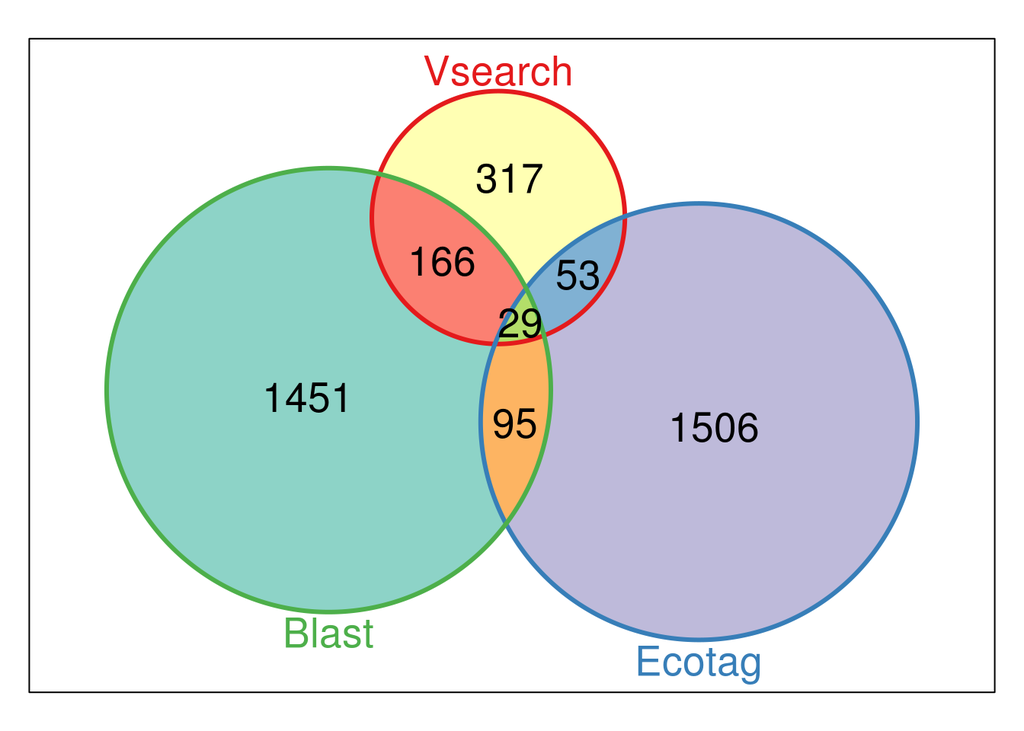

```r
grid.newpage()
#draw.triple.venn(area1 = uniq_vsearch_tseqs_len, area2 = uniq_ecotag_tseqs_len, area3 = uniq_blast_tseqs_len,
#    n12 = intersect_len_EV, n23 = interset_len_EB, n13 = intersect_len_VB,
#    n123 = intersect_len, category = c("Vsearch", "Ecotag", "Blast"), lty = "blank",
#    fill = c("#ffffb3", "red", "#bebada"), euler.d = TRUE, overrideTriple = 1, scaled = TRUE)

plot (Venn(vn))
```

```r
print ("Intersection of Assigned OTUs")
```

```
## [1] "Intersection of Assigned OTUs"
```

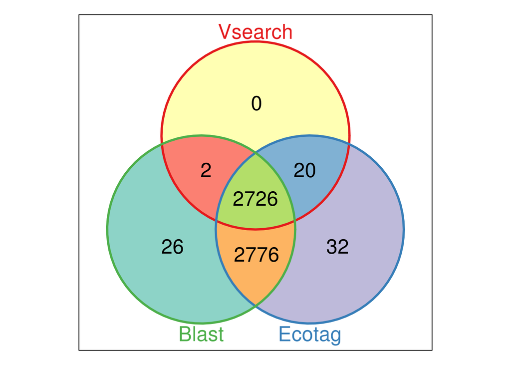

```r
intersect_len_EV <- length (intersect (ovt_ecotag$OTU_SEQID, ovt_vsearch$OTU_SEQID))
interset_len_EB <- length (intersect (ovt_ecotag$OTU_SEQID, ovt_blast$OTU_SEQID))
intersect_len_VB <- length (intersect (ovt_blast$OTU_SEQID, ovt_vsearch$OTU_SEQID))
inter <- intersect (ovt_ecotag$OTU_SEQID, ovt_vsearch$OTU_SEQID)
intersect_len <- length (intersect (inter, ovt_blast$OTU_SEQID))

vn_otu <- list (0)
vn_otu[[1]] <- ovt_vsearch$OTU_SEQID
vn_otu[[2]] <- ovt_ecotag$OTU_SEQID
vn_otu[[3]] <- ovt_blast$OTU_SEQID
names (vn_otu) <- c ("Vsearch", "Ecotag", "Blast")


grid.newpage()
#draw.triple.venn(area1 = nrow (ovt_vsearch), area2 = nrow (ovt_ecotag), area3 = nrow (ovt_blast),
#    n12 = intersect_len_EV, n23 = interset_len_EB, n13 = intersect_len_VB,
#    n123 = intersect_len, category = c("Vsearch", "Ecotag", "Blast"), lty = "blank",
#    fill = c("#ffffb3", "red", "#bebada"))

plot (Venn (vn_otu), doWeights = FALSE)
```

## Investigate phylogenetic levels of taxonomic assingment of OTUs

The following table shows, for each phylogenetic level, the number of OTU assignments where that level was the lowest assignment. This table may also reveal issues where there is not lowest. This could be some kind of error with the assignment, or a behavior of the assignment package. For example, ecotag keeps all data in the results. The sequences that it cannot assign, it assigns to the “root” of the phylogenetic tree.

```r
taxonomicRanksOfInterest <- c ("species", "genus", "family", "order", "class", "phylum", "kingdom")

# Vsearch
vsearch_taxonomy <- ovt_vsearch[,taxonomicRanksOfInterest]
vsearch_best_match_scinames <- apply(vsearch_taxonomy, 1, function(x) head(x[x != ""], 1))

vsearch_best_match_scinames <- unlist (lapply(X = vsearch_best_match_scinames,
                                      function (x) ifelse(length(x) == 0, "", x[1])))
vsearch_best_match_levels <- apply(vsearch_taxonomy, 1, function(x) names(head(x[x != ""], 1)))
vsearch_best_match_levels <- unlist (lapply(X = vsearch_best_match_levels,
                                      function (x) ifelse(length(x) == 0, "", x[1])))
vsearch_best_match <- cbind.data.frame (ovt_vsearch$OTU_SEQID,
                                        vsearch_best_match_scinames, vsearch_best_match_levels)
colnames (vsearch_best_match) <- c ("OTU_SEQID", "SCINAME", "LEVEL")


# Ecotag
ecotag_taxonomy <- ovt_ecotag[,taxonomicRanksOfInterest]
ecotag_best_match_scinames <- apply(ecotag_taxonomy, 1, function(x) head(x[x != ""], 1))

ecotag_best_match_scinames <- unlist (lapply(X = ecotag_best_match_scinames,
                                      function (x) ifelse(length(x) == 0, "", x[1])))
ecotag_best_match_levels <- apply(ecotag_taxonomy, 1, function(x) names(head(x[x != ""], 1)))
ecotag_best_match_levels <- unlist (lapply(X = ecotag_best_match_levels,
                                      function (x) ifelse(length(x) == 0, "", x[1])))
ecotag_best_match <- cbind.data.frame (ovt_ecotag$OTU_SEQID,
                                        ecotag_best_match_scinames, ecotag_best_match_levels)
colnames (ecotag_best_match) <- c ("OTU_SEQID", "SCINAME", "LEVEL")


# Blast
blast_taxonomy <- ovt_blast[,taxonomicRanksOfInterest]
blast_best_match_scinames <- apply(blast_taxonomy, 1, function(x) head(x[x != ""], 1))

blast_best_match_scinames <- unlist (lapply(X = blast_best_match_scinames,
                                      function (x) ifelse(length(x) == 0, "", x[1])))
blast_best_match_levels <- apply(blast_taxonomy, 1, function(x) names(head(x[x != ""], 1)))
blast_best_match_levels <- unlist (lapply(X = blast_best_match_levels,
                                      function (x) ifelse(length(x) == 0, "", x[1])))
blast_best_match <- cbind.data.frame (ovt_blast$OTU_SEQID,
                                        blast_best_match_scinames, blast_best_match_levels)
colnames (blast_best_match) <- c ("OTU_SEQID", "SCINAME", "LEVEL")




taxon_level_counts_vsearch <- sapply (X = taxonomicRanksOfInterest,
                                      FUN = function (x) length (which(vsearch_best_match$LEVEL == x)))
taxon_level_counts_ecotag <- sapply (X = taxonomicRanksOfInterest,
                                     FUN = function (x) length (which(ecotag_best_match$LEVEL == x)))
taxon_level_counts_blast <- sapply (X = taxonomicRanksOfInterest,
                                     FUN = function (x) length (which(blast_best_match$LEVEL == x)))

empty_taxon_count_vsearch <- length (which (vsearch_best_match$LEVEL == ""))
empty_taxon_count_ecotag <- length (which (ecotag_best_match$LEVEL == ""))
empty_taxon_count_blast <- length (which (blast_best_match$LEVEL == ""))
empty_counts <- c (empty_taxon_count_vsearch, empty_taxon_count_ecotag, empty_taxon_count_blast)


total_count_vsearch <- sum (taxon_level_counts_vsearch) + empty_taxon_count_vsearch
total_count_ecotag <- sum (taxon_level_counts_ecotag) + empty_taxon_count_ecotag
total_count_blast <- sum (taxon_level_counts_blast) + empty_taxon_count_blast
total_counts <- c (total_count_vsearch, total_count_ecotag, total_count_blast)


# ASSERTION: total_counts should equal the nrow (ovt_XXX)

titles_col <- c ("Vsearch", "Ecotag", "Blast")
counts_table <- rbind.data.frame (taxon_level_counts_vsearch, taxon_level_counts_ecotag, taxon_level_counts_blast)
counts_table <- cbind.data.frame(titles_col, counts_table, empty_counts, total_counts)
colnames (counts_table) <- c ("Source", taxonomicRanksOfInterest, "unassigned", "total")


print (counts_table)
```

```
##    Source species genus family order class phylum kingdom unassigned total
## 1 Vsearch    2741     1      0     0     0      0       0          6  2748
## 2  Ecotag     461   352    305   196   558   1097    2176        409  5554
## 3   Blast    5529     1      0     0     0      0       0          0  5530
```

## Investigate identity scores

BLAST, Vsearch and Ecotag each return an identity score.

The Vsearch parameters specified a minimum identity score of 0.7.

The Ecotag parameters specified a minumum identity score of 0.7.

The BLAST parameters specified a minimum identity score of 0. (????)

The following is intended to see if the assignment methods give similar identity scores when assigned to the same reference sequence, as well as the overall spread of identity scores.

```r
## Get each assigned OTU with identity score
otu_identity_vsearch <- cbind.data.frame (ovt_vsearch$OTU_SEQID,
                        ovt_vsearch$VSEARCH_IDENTITY_NT, ovt_vsearch$REF_SEQID)
colnames (otu_identity_vsearch) <- c ("OTU_SEQID", "VSEARCH_IDENTITY_NT", "VSEARCH_REF_SEQID")


otu_identity_ecotag <- cbind.data.frame (ovt_ecotag$OTU_SEQID,
                        ovt_ecotag$ECOTAG_IDENTITY_NT, ovt_ecotag$REF_SEQID)
colnames (otu_identity_ecotag) <- c ("OTU_SEQID", "ECOTAG_IDENTITY_NT", "ECOTAG_REF_SEQID")


otu_identity_blast <- cbind.data.frame (ovt_blast$OTU_SEQID,
                        ovt_blast$BLAST_IDENTITY_NT, ovt_blast$REF_SEQID)
colnames (otu_identity_blast) <- c ("OTU_SEQID", "BLAST_IDENTITY_NT", "BLAST_REF_SEQID")


# Together such that each OTU has all identity scores
otu_identity_EV <- merge (x = otu_identity_vsearch, y = otu_identity_ecotag, by = "OTU_SEQID")
otu_identity_VB <- merge (x = otu_identity_vsearch, y = otu_identity_blast, by = "OTU_SEQID")
otu_identity_EB <- merge (x = otu_identity_ecotag, y = otu_identity_blast, by = "OTU_SEQID")
otu_identity_EVB <- merge (x = otu_identity_EV, y = otu_identity_blast,  by = "OTU_SEQID")
```

*Plot the identity scores for each method separately (intersection of OTUs).*

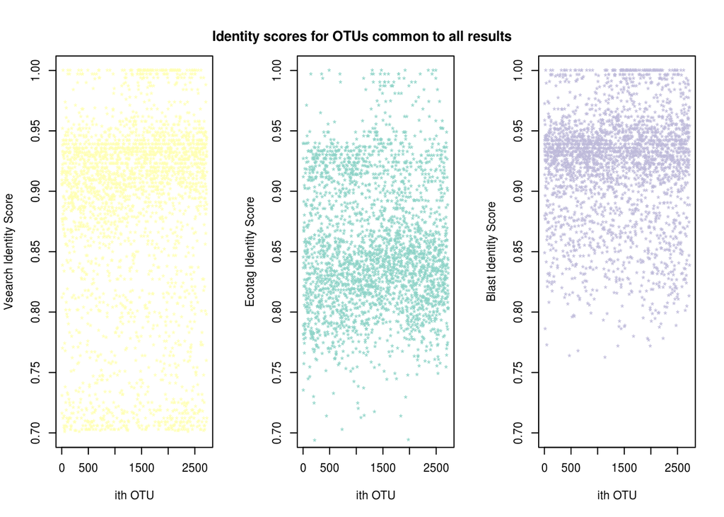

```r
par(mfrow=c(1,3))
plot (x = rownames(otu_identity_EVB), y = otu_identity_EVB$VSEARCH_IDENTITY_NT / 100,
      ylim = c(0.7,1), col = "#ffffb3", pch = '*',
      ylab = "Vsearch Identity Score", xlab = "ith OTU")
plot (x = rownames(otu_identity_EVB), y = otu_identity_EVB$ECOTAG_IDENTITY_NT,
      ylim = c(0.7, 1), col = "#8dd3c7", pch = '*',
      ylab = "Ecotag Identity Score", xlab = "ith OTU")
plot (x = rownames(otu_identity_EVB), y = otu_identity_EVB$BLAST_IDENTITY_NT / 100,
      ylim = c(0.7, 1), col = "#bebada", pch = '*',
      ylab = "Blast Identity Score", xlab = "ith OTU")
title("Identity scores for OTUs common to all results", outer=TRUE, line = -3)
```

*Plot the identity scores for each method together (intersection of OTUs).*

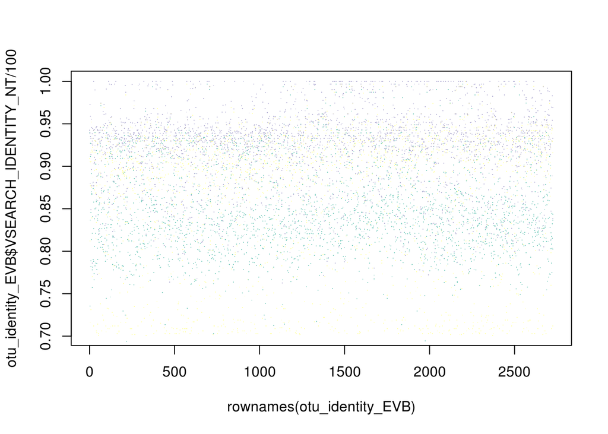

```r
plot (x = rownames(otu_identity_EVB), y = otu_identity_EVB$VSEARCH_IDENTITY_NT / 100, col = "#ffffb3", pch = '.')
points (x = rownames(otu_identity_EVB), y = otu_identity_EVB$ECOTAG_IDENTITY_NT, col = "#8dd3c7", pch = '.')
points (x = rownames(otu_identity_EVB), y = otu_identity_EVB$BLAST_IDENTITY_NT / 100, col = "#bebada", pch = '.')
```

*Compare the identity scores of the OTU intersections*

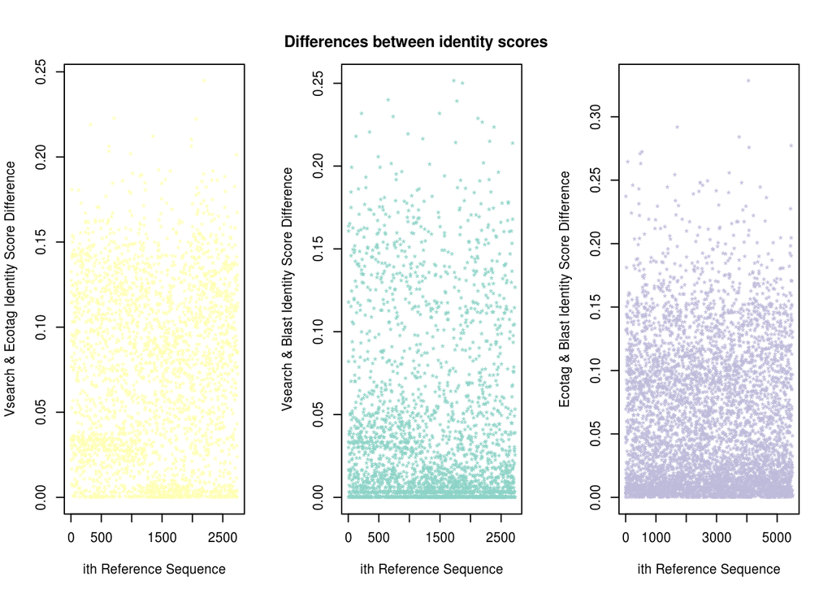

```r
otu_identity_EV$VSEARCH_IDENTITY_NT <- otu_identity_EV$VSEARCH_IDENTITY_NT / 100
otu_identity_VB$VSEARCH_IDENTITY_NT <- otu_identity_VB$VSEARCH_IDENTITY_NT / 100
otu_identity_VB$BLAST_IDENTITY_NT <- otu_identity_VB$BLAST_IDENTITY_NT / 100
otu_identity_EB$BLAST_IDENTITY_NT <- otu_identity_EB$BLAST_IDENTITY_NT / 100
otu_identity_EVB$BLAST_IDENTITY_NT <- otu_identity_EVB$BLAST_IDENTITY_NT / 100
otu_identity_EVB$SEARCH_IDENTITY_NT <- otu_identity_EVB$VSEARCH_IDENTITY_NT / 100


num_same_OTU_EV <- nrow (otu_identity_EV)
num_same_OTU_VB <- nrow (otu_identity_VB)
num_same_OTU_EB <- nrow (otu_identity_EB)

par(mfrow=c(1,3))

identity_diffs_EV <-
  abs (otu_identity_EV$VSEARCH_IDENTITY_NT - otu_identity_EV$ECOTAG_IDENTITY_NT)
plot (x = seq (1:nrow (otu_identity_EV)), y = identity_diffs_EV, col = "#ffffb3", pch = '*',
      ylab = "Vsearch & Ecotag Identity Score Difference", xlab = "ith Reference Sequence")

identity_diffs_VB <-
  abs (otu_identity_VB$VSEARCH_IDENTITY_NT - otu_identity_VB$BLAST_IDENTITY_NT )
plot (x = seq (1:nrow (otu_identity_VB)), y = identity_diffs_VB, col = "#8dd3c7", pch = '*',
      ylab = "Vsearch & Blast Identity Score Difference", xlab = "ith Reference Sequence")

identity_diffs_EB <-
  abs (otu_identity_EB$ECOTAG_IDENTITY_NT - otu_identity_EB$BLAST_IDENTITY_NT)
plot (x = seq (1:nrow (otu_identity_EB)), y = identity_diffs_EB, col = "#bebada", pch = '*',
      ylab = "Ecotag & Blast Identity Score Difference", xlab = "ith Reference Sequence")

title("Differences between identity scores", outer=TRUE, line = -3)
```

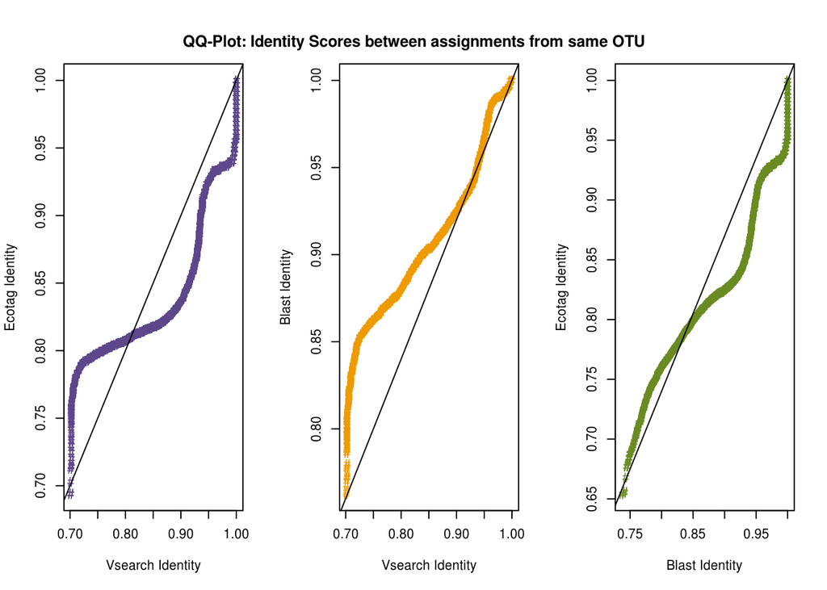

```r
par(mfrow=c(1,3))
qqplot(x = otu_identity_EV$VSEARCH_IDENTITY_NT, y = otu_identity_EV$ECOTAG_IDENTITY_NT, plot.it = TRUE,
       ylab = "Ecotag Identity", xlab = "Vsearch Identity", col = "mediumpurple4", pch = '#')
abline(a=0, b = 1)

qqplot(x = otu_identity_VB$VSEARCH_IDENTITY_NT, y = otu_identity_VB$BLAST_IDENTITY_NT, plot.it = TRUE,
       ylab = "Blast Identity", xlab = "Vsearch Identity", col = "orange2", pch = '#')
abline(a=.2, b=.8 )

qqplot(x = otu_identity_EB$BLAST_IDENTITY_NT, y = otu_identity_EB$ECOTAG_IDENTITY_NT, plot.it = TRUE,
       ylab = "Ecotag Identity", xlab = "Blast Identity", col = "olivedrab4", pch = '#')
abline(a=-.3 , b=1.3)


title("QQ-Plot: Identity Scores between assignments from same OTU", outer=TRUE, line = -3)
```

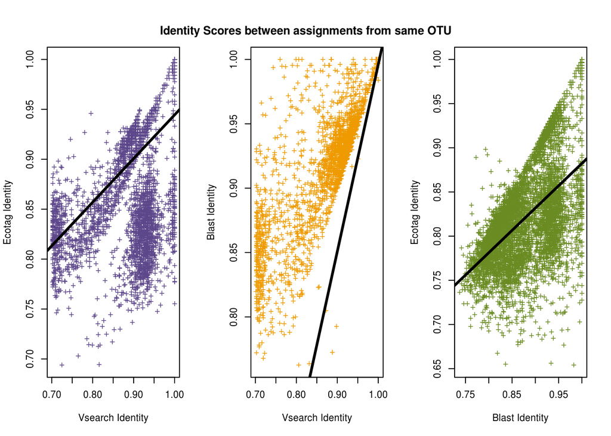

```r
par(mfrow=c(1,3))
plot(x = otu_identity_EV$VSEARCH_IDENTITY_NT, y = otu_identity_EV$ECOTAG_IDENTITY_NT,
       ylab = "Ecotag Identity", xlab = "Vsearch Identity", col = "mediumpurple4", pch = '+')
# Fit regression line
abline (lm(VSEARCH_IDENTITY_NT ~ ECOTAG_IDENTITY_NT, data = otu_identity_EV), lwd = 3)

plot(x = otu_identity_VB$VSEARCH_IDENTITY_NT, y = otu_identity_VB$BLAST_IDENTITY_NT,
       ylab = "Blast Identity", xlab = "Vsearch Identity", col = "orange2", pch = '+')
# Fit regression line
abline (lm(VSEARCH_IDENTITY_NT ~ BLAST_IDENTITY_NT, data = otu_identity_VB), lwd = 3)

plot(x = otu_identity_EB$BLAST_IDENTITY_NT, y = otu_identity_EB$ECOTAG_IDENTITY_NT,
       ylab = "Ecotag Identity", xlab = "Blast Identity", col = "olivedrab4", pch = '+')
# Fit regression line
abline (lm(ECOTAG_IDENTITY_NT ~ BLAST_IDENTITY_NT, data = otu_identity_EB), lwd = 3)

title("Identity Scores between assignments from same OTU", outer=TRUE, line = -3)
```

*2-sample t-test between Ecotag Identity and Vsearch Identity for same OTUs*

```r
var.test(x = otu_identity_EV$VSEARCH_IDENTITY_NT, y = otu_identity_EV$ECOTAG_IDENTITY_NT)
```

```
##
##  F test to compare two variances
##
## data:  otu_identity_EV$VSEARCH_IDENTITY_NT and otu_identity_EV$ECOTAG_IDENTITY_NT
## F = 2.3874, num df = 2745, denom df = 2745, p-value < 2.2e-16
## alternative hypothesis: true ratio of variances is not equal to 1
## 95 percent confidence interval:
##  2.215217 2.572860
## sample estimates:
## ratio of variances
##           2.387351
```

```r
t.test(otu_identity_EV$VSEARCH_IDENTITY_NT, otu_identity_EV$ECOTAG_IDENTITY_NT, var.equal=FALSE, paired=TRUE, alternative = "two.sided")
```

```
##
##  Paired t-test
##
## data:  otu_identity_EV$VSEARCH_IDENTITY_NT and otu_identity_EV$ECOTAG_IDENTITY_NT
## t = 16.832, df = 2745, p-value < 2.2e-16
## alternative hypothesis: true difference in means is not equal to 0
## 95 percent confidence interval:
##  0.02384283 0.03013028
## sample estimates:
## mean of the differences
##              0.02698655
```

*2-sample t-test between Blast Identity and Vsearch Identity for same OTUs*

```r
var.test(x = otu_identity_VB$VSEARCH_IDENTITY_NT, y = otu_identity_VB$BLAST_IDENTITY_NT)
```

```
##
##  F test to compare two variances
##
## data:  otu_identity_VB$VSEARCH_IDENTITY_NT and otu_identity_VB$BLAST_IDENTITY_NT
## F = 3.189, num df = 2727, denom df = 2727, p-value < 2.2e-16
## alternative hypothesis: true ratio of variances is not equal to 1
## 95 percent confidence interval:
##  2.958342 3.437656
## sample estimates:
## ratio of variances
##           3.189006
```

```r
t.test(otu_identity_VB$VSEARCH_IDENTITY_NT, otu_identity_VB$BLAST_IDENTITY_NT, var.equal=FALSE, paired=TRUE, alternative = "two.sided")
```

```
##
##  Paired t-test
##
## data:  otu_identity_VB$VSEARCH_IDENTITY_NT and otu_identity_VB$BLAST_IDENTITY_NT
## t = -40.347, df = 2727, p-value < 2.2e-16
## alternative hypothesis: true difference in means is not equal to 0
## 95 percent confidence interval:
##  -0.04172893 -0.03786096
## sample estimates:
## mean of the differences
##             -0.03979494
```

```r
var.test(x = otu_identity_EB$BLAST_IDENTITY_NT, y = otu_identity_EB$ECOTAG_IDENTITY_NT)
```

```
##
##  F test to compare two variances
##
## data:  otu_identity_EB$BLAST_IDENTITY_NT and otu_identity_EB$ECOTAG_IDENTITY_NT
## F = 1.2037, num df = 5501, denom df = 5501, p-value = 6.384e-12
## alternative hypothesis: true ratio of variances is not equal to 1
## 95 percent confidence interval:
##  1.141746 1.269055
## sample estimates:
## ratio of variances
##           1.203719
```

```r
t.test(otu_identity_EB$BLAST_IDENTITY_NT, otu_identity_EB$ECOTAG_IDENTITY_NT, var.equal=FALSE, paired=TRUE, alternative = "two.sided")
```

```
##
##  Paired t-test
##
## data:  otu_identity_EB$BLAST_IDENTITY_NT and otu_identity_EB$ECOTAG_IDENTITY_NT
## t = 77.935, df = 5501, p-value < 2.2e-16
## alternative hypothesis: true difference in means is not equal to 0
## 95 percent confidence interval:
##  0.05607633 0.05897023
## sample estimates:
## mean of the differences
##              0.05752328
```

In order to better compare, select OTUs that assigned to the same reference sequences with different methods.

```r
otu_EV_same_refseq <- otu_identity_EV[as.character (otu_identity_EV$VSEARCH_REF_SEQID) == as.character (otu_identity_EV$ECOTAG_REF_SEQID),]
otu_EV_same_refseq <- otu_EV_same_refseq[complete.cases(otu_EV_same_refseq),]
num_same_ref_seq_EV <- nrow (otu_EV_same_refseq)

otu_VB_same_refseq <- otu_identity_VB[ as.character (otu_identity_VB$VSEARCH_REF_SEQID) == as.character (otu_identity_VB$BLAST_REF_SEQID),]
otu_VB_same_refseq <- otu_VB_same_refseq[complete.cases(otu_VB_same_refseq),]
num_same_ref_seq_VB <- nrow (otu_VB_same_refseq)

otu_EB_same_refseq <- otu_identity_EB[ as.character (otu_identity_EB$ECOTAG_REF_SEQID) == as.character (otu_identity_EB$BLAST_REF_SEQID),]
otu_EB_same_refseq <- otu_EB_same_refseq[complete.cases(otu_EB_same_refseq),]
num_same_ref_seq_EB <- nrow (otu_EB_same_refseq)
```

Vsearch and Ecotag share 226 assignments to the same reference sequence.

Vsearch and Blast share 1000 assignments to the same reference sequence.

Ecotag and Blast share 235 assignments to the same reference sequence.

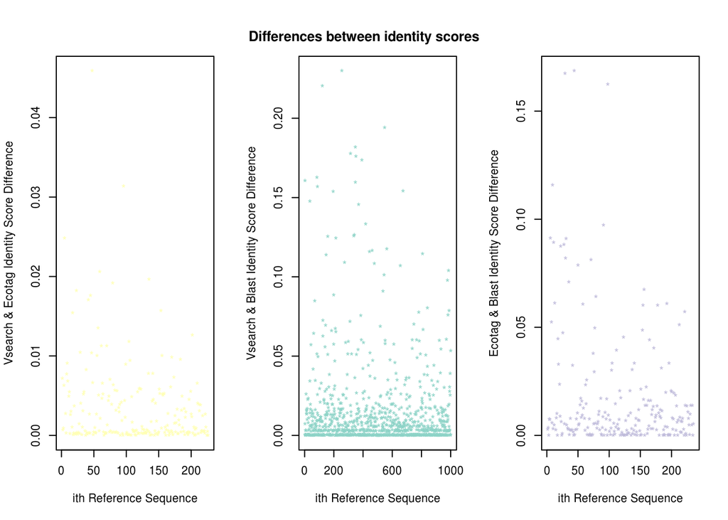

```r
par(mfrow=c(1,3))

identity_diffs_EV <-
  abs (otu_EV_same_refseq$VSEARCH_IDENTITY_NT- otu_EV_same_refseq$ECOTAG_IDENTITY_NT)
plot (x = seq (1:nrow (otu_EV_same_refseq)), y = identity_diffs_EV, col = "#ffffb3", pch = '*',
      ylab = "Vsearch & Ecotag Identity Score Difference", xlab = "ith Reference Sequence")

identity_diffs_VB <-
  abs (otu_VB_same_refseq$VSEARCH_IDENTITY_NT - otu_VB_same_refseq$BLAST_IDENTITY_NT)
plot (x = seq (1:nrow (otu_VB_same_refseq)), y = identity_diffs_VB, col = "#8dd3c7", pch = '*',
      ylab = "Vsearch & Blast Identity Score Difference", xlab = "ith Reference Sequence")

identity_diffs_EB <-
  abs (otu_EB_same_refseq$BLAST_IDENTITY_NT - otu_EB_same_refseq$ECOTAG_IDENTITY_NT)
plot (x = seq (1:nrow (otu_EB_same_refseq)), y = identity_diffs_EB, col = "#bebada", pch = '*',
      ylab = "Ecotag & Blast Identity Score Difference", xlab = "ith Reference Sequence")


title("Differences between identity scores", outer=TRUE, line = -3)
```

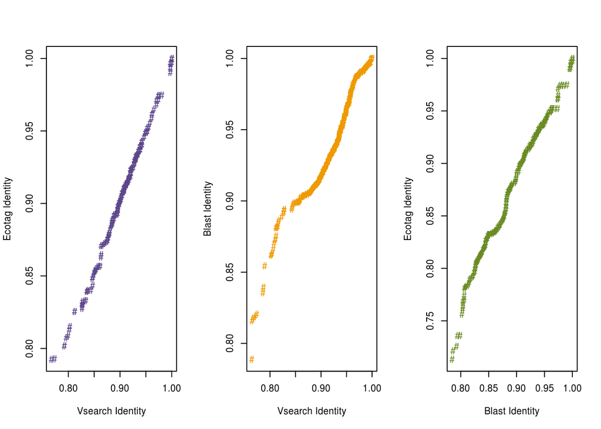

```r
par(mfrow=c(1,3))
qqplot(x = otu_EV_same_refseq$VSEARCH_IDENTITY_NT, y = otu_EV_same_refseq$ECOTAG_IDENTITY_NT, plot.it = TRUE,
       ylab = "Ecotag Identity", xlab = "Vsearch Identity", col = "mediumpurple4", pch = '#')

qqplot(x = otu_VB_same_refseq$VSEARCH_IDENTITY_NT, y = otu_VB_same_refseq$BLAST_IDENTITY_NT, plot.it = TRUE,
       ylab = "Blast Identity", xlab = "Vsearch Identity", col = "orange2", pch = '#')

qqplot(x = otu_EB_same_refseq$BLAST_IDENTITY_NT, y = otu_EB_same_refseq$ECOTAG_IDENTITY_NT, plot.it = TRUE,
       ylab = "Ecotag Identity", xlab = "Blast Identity", col = "olivedrab4", pch = '#')
```

*2-sample t-test between Ecotag Identity and Vsearch Identity for matched reference sequence*

```r
var.test(x = otu_EV_same_refseq$VSEARCH_IDENTITY_NT, y = otu_EV_same_refseq$ECOTAG_IDENTITY_NT)
```

```
##
##  F test to compare two variances
##
## data:  otu_EV_same_refseq$VSEARCH_IDENTITY_NT and otu_EV_same_refseq$ECOTAG_IDENTITY_NT
## F = 1.103, num df = 225, denom df = 225, p-value = 0.4629
## alternative hypothesis: true ratio of variances is not equal to 1
## 95 percent confidence interval:
##  0.8487511 1.4333213
## sample estimates:
## ratio of variances
##           1.102966
```

```r
t.test(otu_EV_same_refseq$VSEARCH_IDENTITY_NT, otu_EV_same_refseq$ECOTAG_IDENTITY_NT, var.equal=TRUE, paired=TRUE, alternative = "two.sided")
```

```
##
##  Paired t-test
##
## data:  otu_EV_same_refseq$VSEARCH_IDENTITY_NT and otu_EV_same_refseq$ECOTAG_IDENTITY_NT
## t = -2.7883, df = 225, p-value = 0.005753
## alternative hypothesis: true difference in means is not equal to 0
## 95 percent confidence interval:
##  -0.0020439936 -0.0003512114
## sample estimates:
## mean of the differences
##            -0.001197602
```

*2-sample t-test between Blast Identity and Vsearch Identity for matched reference sequence*

```r
var.test(x = otu_VB_same_refseq$VSEARCH_IDENTITY_NT, y = otu_VB_same_refseq$BLAST_IDENTITY_NT)
```

```
##
##  F test to compare two variances
##
## data:  otu_VB_same_refseq$VSEARCH_IDENTITY_NT and otu_VB_same_refseq$BLAST_IDENTITY_NT
## F = 1.5925, num df = 999, denom df = 999, p-value = 2.491e-13
## alternative hypothesis: true ratio of variances is not equal to 1
## 95 percent confidence interval:
##  1.406695 1.802955
## sample estimates:
## ratio of variances
##           1.592548
```

```r
t.test(otu_VB_same_refseq$VSEARCH_IDENTITY_NT, otu_VB_same_refseq$BLAST_IDENTITY_NT , var.equal=FALSE, paired=TRUE, alternative = "two.sided")
```

```
##
##  Paired t-test
##
## data:  otu_VB_same_refseq$VSEARCH_IDENTITY_NT and otu_VB_same_refseq$BLAST_IDENTITY_NT
## t = -15.745, df = 999, p-value < 2.2e-16
## alternative hypothesis: true difference in means is not equal to 0
## 95 percent confidence interval:
##  -0.01580985 -0.01230575
## sample estimates:
## mean of the differences
##              -0.0140578
```

```r
var.test(x = otu_EB_same_refseq$BLAST_IDENTITY_NT, y = otu_EB_same_refseq$ECOTAG_IDENTITY_NT)
```

```
##
##  F test to compare two variances
##
## data:  otu_EB_same_refseq$BLAST_IDENTITY_NT and otu_EB_same_refseq$ECOTAG_IDENTITY_NT
## F = 0.72871, num df = 234, denom df = 234, p-value = 0.01582
## alternative hypothesis: true ratio of variances is not equal to 1
## 95 percent confidence interval:
##  0.5636324 0.9421462
## sample estimates:
## ratio of variances
##           0.728714
```

```r
t.test(otu_EB_same_refseq$BLAST_IDENTITY_NT , otu_EB_same_refseq$ECOTAG_IDENTITY_NT, var.equal=FALSE, paired=TRUE, alternative = "two.sided")
```

```
##
##  Paired t-test
##
## data:  otu_EB_same_refseq$BLAST_IDENTITY_NT and otu_EB_same_refseq$ECOTAG_IDENTITY_NT
## t = 9.0814, df = 234, p-value < 2.2e-16
## alternative hypothesis: true difference in means is not equal to 0
## 95 percent confidence interval:
##  0.01298119 0.02017398
## sample estimates:
## mean of the differences
##              0.01657758
```

# Part 2: Filtered Results

## Filter singletons, etc

In order to reduce amount of junk assignments, remove based on the following criteria:

1. Singleton (type 1): The read count across all samples is 1
2. Singleton (type 2): The read count in any single sample is never > 1
3. Singleton (type 3): The read count in any single sample is never greater than 1% of total count across all samples

```r
## Filter singleton (type 1)

singleton_1_vsearch_length <- nrow (ovt_vsearch[ovt_vsearch$TOTAL == 1,])
ovt_vsearch <- ovt_vsearch[ovt_vsearch$TOTAL > 1,]

singleton_1_ecotag_length <- nrow (ovt_ecotag[ovt_ecotag$TOTAL == 1,])
ovt_ecotag <- ovt_ecotag[ovt_ecotag$TOTAL > 1,]

singleton_1_blast_length <- nrow (ovt_blast[ovt_blast$TOTAL == 1,])
ovt_blast <- ovt_blast[ovt_blast$TOTAL > 1,]


## Filter singleton (type 2)

singleton_2_vsearch_length <- nrow (ovt_vsearch[apply(ovt_vsearch[,sample_vsearch_idx], 1, function(row) {all(row <= 1)}),])
ovt_vsearch <- ovt_vsearch[apply(ovt_vsearch[,sample_vsearch_idx], 1, function(row) {any(row > 1)}),]

singleton_2_ecotag_length <- nrow (ovt_ecotag[apply(ovt_ecotag[,sample_ecotag_idx], 1, function(row) {all(row <= 1)}),])
ovt_ecotag <- ovt_ecotag[apply(ovt_ecotag[,sample_ecotag_idx], 1, function(row) {any(row > 1)}),]

singleton_2_blast_length <- nrow (ovt_blast[apply(ovt_blast[,sample_blast_idx], 1, function(row) {all(row <= 1)}),])
ovt_blast <- ovt_blast[apply(ovt_blast[,sample_blast_idx], 1, function(row) {any(row > 1)}),]

## Filter singleton (type 3)

singleton_3_vsearch_length <- nrow (ovt_vsearch [apply(ovt_vsearch[,sample_vsearch_idx], 1, function(row) {  all( .01 >= (row/sum(row) ) ) }), ])
ovt_vsearch <- ovt_vsearch [apply(ovt_vsearch[,sample_vsearch_idx], 1, function(row) {  any( .01 < (row/sum(row) ) ) }), ]

singleton_3_ecotag_length <- nrow (ovt_ecotag [apply(ovt_ecotag[,sample_ecotag_idx], 1, function(row) {  all( .01 >= (row/sum(row) ) ) }), ])
ovt_ecotag <- ovt_ecotag [apply(ovt_ecotag[,sample_ecotag_idx], 1, function(row) {  any( .01 < (row/sum(row) ) ) }), ]

singleton_3_blast_length <- nrow (ovt_blast [apply(ovt_blast[,sample_blast_idx], 1, function(row) {  all( .01 >= (row/sum(row) ) ) }), ])
ovt_blast <- ovt_blast [apply(ovt_blast[,sample_blast_idx], 1, function(row) {  any( .01 < (row/sum(row) ) ) }), ]

# Total the filtered OTUs
total_filtered_vsearch <- singleton_1_vsearch_length + singleton_2_vsearch_length + singleton_3_vsearch_length
total_filtered_ecotag <- singleton_1_ecotag_length + singleton_2_ecotag_length + singleton_3_ecotag_length
total_filtered_blast <- singleton_1_blast_length + singleton_2_blast_length + singleton_3_blast_length
```

Need to print this info

|  | Vsearch | Ecotag | Blast |
| --- | --- | --- | --- |
| Singletons (type 1) | 2054 | 4393 | 4382 |
| Singletons (type 2) | 225 | 341 | 340 |
| Singletons (type 3) | 0 | 0 | 0 |
| Total Filtered OTUs | 2279 | 4734 | 4722 |
| Remaining OTUs | 469 | 819 | 807 |

## Overview

```r
total_OTUs <- length (OTUs)

uniq_vsearch_tseqs <- unique(ovt_vsearch$REF_SEQID)
uniq_ecotag_tseqs <- unique(ovt_ecotag$REF_SEQID)
uniq_blast_tseqs <- unique(ovt_blast$REF_SEQID)

uniq_vsearch_tseqs_len <- length (uniq_vsearch_tseqs)
uniq_ecotag_tseqs_len <- length (uniq_ecotag_tseqs)
uniq_blast_tseqs_len <- length (uniq_blast_tseqs)

intersect_len_EV <- length (intersect (uniq_vsearch_tseqs, uniq_ecotag_tseqs))
interset_len_EB <- length (intersect (uniq_blast_tseqs, uniq_ecotag_tseqs))
intersect_len_VB <- length (intersect (uniq_vsearch_tseqs, uniq_blast_tseqs))
inter <- intersect (uniq_vsearch_tseqs, uniq_ecotag_tseqs)
intersect_len <- length (intersect (inter, uniq_blast_tseqs))

vn <- list (0)
vn[[1]] <- uniq_vsearch_tseqs
vn[[2]] <- uniq_ecotag_tseqs
vn[[3]] <- uniq_blast_tseqs
names (vn) <- c ("Vsearch", "Ecotag", "Blast")
```

The following table compares the number of OTUs present in the data produced for each method of taxonomic assignment. This does not take into account possible erroneous/problematic assignments as these will be discovered and addressed as part of this evaluation process.

In addition, the table shows the number of unique reference assignments for each assignment method, as well as the intersection of all three: the number of OTUs that were assigned to the same reference sequence.

|  | Vsearch | Ecotag | Blast |
| --- | --- | --- | --- |
| Number of Assigned OTUs | 469 | 819 | 807 |
| Total OTUs | 5636 | 5636 | 5636 |
| Percent Assigned OTUs | 8.3215046 | 14.5315827 | 14.3186657 |
| Unique Reference Sequences | 285 | 578 | 632 |
| Intersection of Unique Reference Sequences | 17 | 17 | 17 |
| Percent References Sequences Shared | 5.9649123 | 2.9411765 | 2.6898734 |

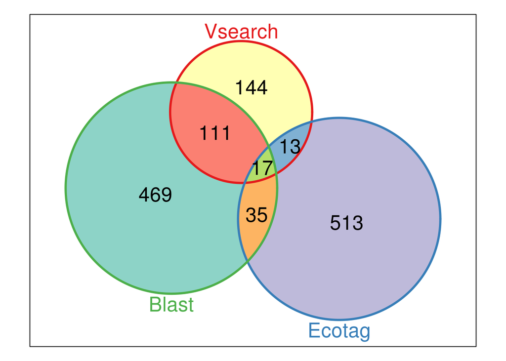

```r
grid.newpage()
#draw.triple.venn(area1 = uniq_vsearch_tseqs_len, area2 = uniq_ecotag_tseqs_len, area3 = uniq_blast_tseqs_len,
#    n12 = intersect_len_EV, n23 = interset_len_EB, n13 = intersect_len_VB,
#    n123 = intersect_len, category = c("Vsearch", "Ecotag", "Blast"), lty = "blank",
#    fill = c("#ffffb3", "red", "#bebada"))

plot (Venn (vn))
```

```r
print ("Intersection of Assigned OTUs")
```

```
## [1] "Intersection of Assigned OTUs"
```

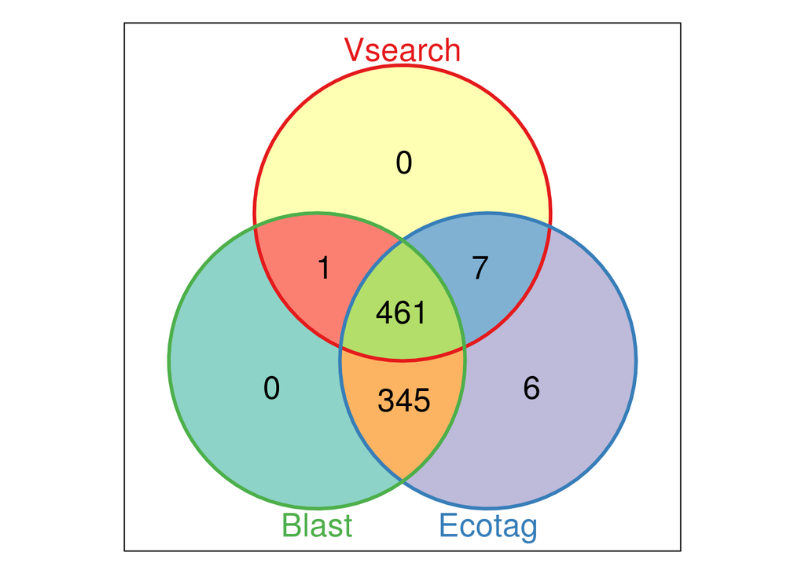

```r
intersect_len_EV <- length (intersect (ovt_ecotag$OTU_SEQID, ovt_vsearch$OTU_SEQID))
interset_len_EB <- length (intersect (ovt_ecotag$OTU_SEQID, ovt_blast$OTU_SEQID))
intersect_len_VB <- length (intersect (ovt_blast$OTU_SEQID, ovt_vsearch$OTU_SEQID))
inter <- intersect (ovt_ecotag$OTU_SEQID, ovt_vsearch$OTU_SEQID)
intersect_len <- length (intersect (inter, ovt_blast$OTU_SEQID))

#grid.newpage()
#draw.triple.venn(area1 = nrow (ovt_vsearch), area2 = nrow (ovt_ecotag), area3 = nrow (ovt_blast),
#    n12 = intersect_len_EV, n23 = interset_len_EB, n13 = intersect_len_VB,
#    n123 = intersect_len, category = c("Vsearch", "Ecotag", "Blast"), lty = "blank",
#    fill = c("#ffffb3", "red", "#bebada"))

vn_otu <- list (0)
vn_otu[[1]] <- ovt_vsearch$OTU_SEQID
vn_otu[[2]] <- ovt_ecotag$OTU_SEQID
vn_otu[[3]] <- ovt_blast$OTU_SEQID
names (vn_otu) <- c ("Vsearch", "Ecotag", "Blast")

plot (Venn (vn_otu), doWeights = FALSE)
```

## Investigate phylogenetic levels of taxonomic assingment of OTUs

The following table shows, for each phylogenetic level, the number of OTU assignments where that level was the lowest assignment. This table may also reveal issues where there is not lowest. This could be some kind of error with the assignment, or a behavior of the assignment package. For example, ecotag keeps all data in the results. The sequences that it cannot assign, it assigns to the “root” of the phylogenetic tree.

```r
taxonomicRanksOfInterest <- c ("species", "genus", "family", "order", "class", "phylum", "kingdom")

# Vsearch
vsearch_taxonomy <- ovt_vsearch[,taxonomicRanksOfInterest]
vsearch_best_match_scinames <- apply(vsearch_taxonomy, 1, function(x) head(x[x != ""], 1))

vsearch_best_match_scinames <- unlist (lapply(X = vsearch_best_match_scinames,
                                      function (x) ifelse(length(x) == 0, "", x[1])))
vsearch_best_match_levels <- apply(vsearch_taxonomy, 1, function(x) names(head(x[x != ""], 1)))
vsearch_best_match_levels <- unlist (lapply(X = vsearch_best_match_levels,
                                      function (x) ifelse(length(x) == 0, "", x[1])))
vsearch_best_match <- cbind.data.frame (ovt_vsearch$OTU_SEQID,
                                        vsearch_best_match_scinames, vsearch_best_match_levels)
colnames (vsearch_best_match) <- c ("OTU_SEQID", "SCINAME", "LEVEL")


# Ecotag
ecotag_taxonomy <- ovt_ecotag[,taxonomicRanksOfInterest]
ecotag_best_match_scinames <- apply(ecotag_taxonomy, 1, function(x) head(x[x != ""], 1))

ecotag_best_match_scinames <- unlist (lapply(X = ecotag_best_match_scinames,
                                      function (x) ifelse(length(x) == 0, "", x[1])))
ecotag_best_match_levels <- apply(ecotag_taxonomy, 1, function(x) names(head(x[x != ""], 1)))
ecotag_best_match_levels <- unlist (lapply(X = ecotag_best_match_levels,
                                      function (x) ifelse(length(x) == 0, "", x[1])))
ecotag_best_match <- cbind.data.frame (ovt_ecotag$OTU_SEQID,
                                        ecotag_best_match_scinames, ecotag_best_match_levels)
colnames (ecotag_best_match) <- c ("OTU_SEQID", "SCINAME", "LEVEL")


# Blast
blast_taxonomy <- ovt_blast[,taxonomicRanksOfInterest]
blast_best_match_scinames <- apply(blast_taxonomy, 1, function(x) head(x[x != ""], 1))

blast_best_match_scinames <- unlist (lapply(X = blast_best_match_scinames,
                                      function (x) ifelse(length(x) == 0, "", x[1])))
blast_best_match_levels <- apply(blast_taxonomy, 1, function(x) names(head(x[x != ""], 1)))
blast_best_match_levels <- unlist (lapply(X = blast_best_match_levels,
                                      function (x) ifelse(length(x) == 0, "", x[1])))
blast_best_match <- cbind.data.frame (ovt_blast$OTU_SEQID,
                                        blast_best_match_scinames, blast_best_match_levels)
colnames (blast_best_match) <- c ("OTU_SEQID", "SCINAME", "LEVEL")




taxon_level_counts_vsearch <- sapply (X = taxonomicRanksOfInterest,
                                      FUN = function (x) length (which(vsearch_best_match$LEVEL == x)))
taxon_level_counts_ecotag <- sapply (X = taxonomicRanksOfInterest,
                                     FUN = function (x) length (which(ecotag_best_match$LEVEL == x)))
taxon_level_counts_blast <- sapply (X = taxonomicRanksOfInterest,
                                     FUN = function (x) length (which(blast_best_match$LEVEL == x)))

empty_taxon_count_vsearch <- length (which (vsearch_best_match$LEVEL == ""))
empty_taxon_count_ecotag <- length (which (ecotag_best_match$LEVEL == ""))
empty_taxon_count_blast <- length (which (blast_best_match$LEVEL == ""))
empty_counts <- c (empty_taxon_count_vsearch, empty_taxon_count_ecotag, empty_taxon_count_blast)


total_count_vsearch <- sum (taxon_level_counts_vsearch) + empty_taxon_count_vsearch
total_count_ecotag <- sum (taxon_level_counts_ecotag) + empty_taxon_count_ecotag
total_count_blast <- sum (taxon_level_counts_blast) + empty_taxon_count_blast
total_counts <- c (total_count_vsearch, total_count_ecotag, total_count_blast)


# ASSERTION: total_counts should equal the nrow (ovt_XXX)

titles_col <- c ("Vsearch", "Ecotag", "Blast")
counts_table <- rbind.data.frame (taxon_level_counts_vsearch, taxon_level_counts_ecotag, taxon_level_counts_blast)
counts_table <- cbind.data.frame(titles_col, counts_table, empty_counts, total_counts)
colnames (counts_table) <- c ("Source", taxonomicRanksOfInterest, "unassigned", "total")


print (counts_table)
```

```
##    Source species genus family order class phylum kingdom unassigned total
## 1 Vsearch     467     0      0     0     0      0       0          2   469
## 2  Ecotag     136    48     58    74    86    169     187         61   819
## 3   Blast     806     1      0     0     0      0       0          0   807
```

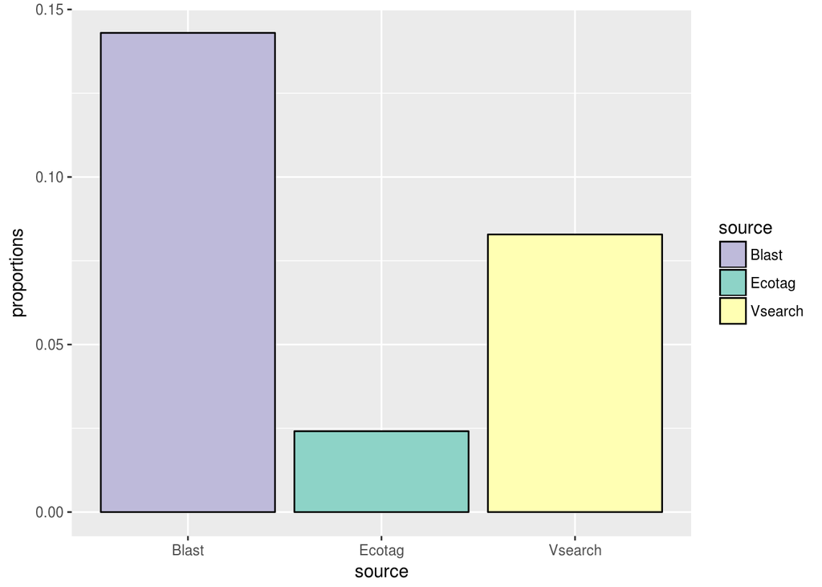

```r
# bar plot of proportion assigned at species level
df <- cbind.data.frame (counts_table$Source, counts_table$species / total_OTUs)
colnames (df) <- c ("source", "proportions")
ggplot (data=df, aes(y=proportions, x=source, fill=source)) + geom_bar(stat="identity", color = "black" ) + scale_fill_manual(values=c("#bebada", "#8dd3c7", "#ffffb3"))
```

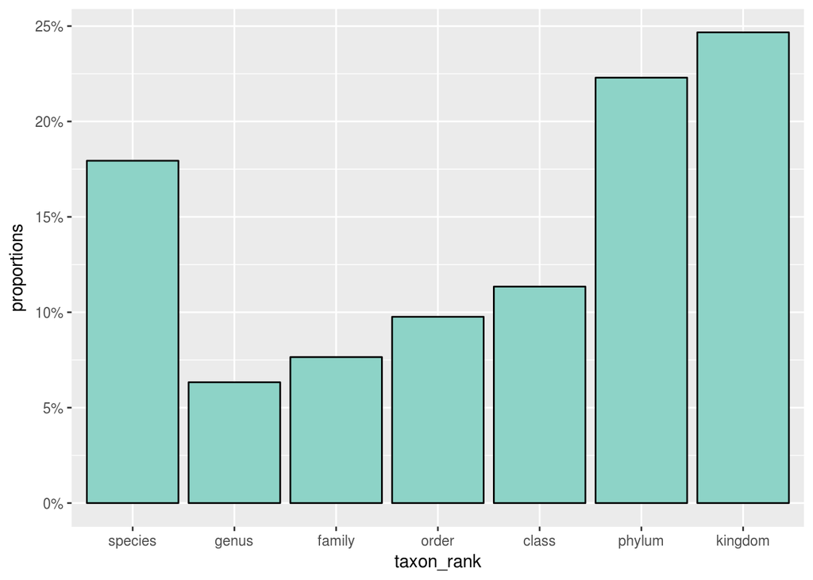

```r
# bar plot rank assignments for Ecotag
proportions <- unlist (counts_table[2,][2:8][1,] / sum (counts_table[2,][2:8][1,] ))
df <- cbind.data.frame (proportions, taxonomicRanksOfInterest)
df <- data.frame(taxon_rank = taxonomicRanksOfInterest, proportions)
ggplot (data=df, aes(y=proportions, x=taxon_rank)) + geom_bar(stat="identity", fill = "#8dd3c7", color = "black") + scale_x_discrete (limits = taxonomicRanksOfInterest) + scale_y_continuous(labels = scales::percent)
```

## Investigate Taxonomy (Before 97% filter)

```r
# Count number of unique ranks per phylogenetic level

uniqRanks <- cbind ( c ("Vsearch", "Ecotag", "Blast"), rbind (
apply(vsearch_taxonomy, MARGIN = 2, FUN = function (x) length (unique(x))),
apply(ecotag_taxonomy, MARGIN = 2, FUN = function (x) length (unique(x))),
apply(blast_taxonomy, MARGIN = 2, FUN = function (x) length (unique(x))) ) )
colnames (uniqRanks)[1] <- "Source"
print (uniqRanks)
```

```
##      Source    species genus family order class phylum kingdom
## [1,] "Vsearch" "253"   "206" "149"  "87"  "34"  "21"   "4"
## [2,] "Ecotag"  "103"   "120" "119"  "79"  "38"  "22"   "4"
## [3,] "Blast"   "583"   "439" "326"  "143" "53"  "27"   "4"
```

```r
intersect_taxonomy <- function (A, B){
  intersect_lens <- c ()
  for (i in taxonomicRanksOfInterest){
    intersect_lens <- c (intersect_lens, ( length ( intersect ( unlist (unique (A[i])), unlist (unique (B[i])) ) )) )
  }
  intersect_lens
}

intersect_taxonomy_three <- function (A, B, C){
  intersect_lens <- c ()
  for (i in taxonomicRanksOfInterest){
    inter_AB <- intersect (unlist (unique (A[i])), unlist (unique (B[i])) )
    intersect_lens <- c (intersect_lens, ( length ( intersect ( inter_AB, unlist (unique (C[i])) ) )) )
  }
  intersect_lens
}

intersect_counts_EV <- intersect_taxonomy(A = vsearch_taxonomy, B = ecotag_taxonomy)
intersect_counts_EB <- intersect_taxonomy(A = ecotag_taxonomy, B = blast_taxonomy)
intersect_counts_BV <- intersect_taxonomy(A = vsearch_taxonomy, B = blast_taxonomy)
intersect_counts_EBV <- intersect_taxonomy_three(A = vsearch_taxonomy, B = ecotag_taxonomy, C = blast_taxonomy)
intersect_counts_table <- cbind.data.frame (intersect_counts_EV, intersect_counts_EB, intersect_counts_BV, intersect_counts_EBV)
colnames (intersect_counts_table) <- c ("Vsearch, Ecotag", "Ecotag, Blast", "Vsearch, Blast", "Vsearch, Ecotag, Blast")

print (intersect_counts_table)
```

```
##   Vsearch, Ecotag Ecotag, Blast Vsearch, Blast Vsearch, Ecotag, Blast
## 1              41            49            159                     36
## 2              65            78            151                     62
## 3              66            88            106                     64
## 4              45            65             69                     44
## 5              25            32             30                     25
## 6              14            20             17                     14
## 7               4             4              4                      4
```

```r
uniqRanks <- cbind ( c ("Vsearch", "Ecotag", "Blast"), rbind (
apply(vsearch_taxonomy, MARGIN = 2, FUN = function (x) length (unique(x))),
apply(ecotag_taxonomy, MARGIN = 2, FUN = function (x) length (unique(x))),
apply(blast_taxonomy, MARGIN = 2, FUN = function (x) length (unique(x))) ) )
colnames (uniqRanks)[1] <- "Source"

print (uniqRanks)
```

```
##      Source    species genus family order class phylum kingdom
## [1,] "Vsearch" "253"   "206" "149"  "87"  "34"  "21"   "4"
## [2,] "Ecotag"  "103"   "120" "119"  "79"  "38"  "22"   "4"
## [3,] "Blast"   "583"   "439" "326"  "143" "53"  "27"   "4"
```

```r
# Get counts of specific unique ranks within a level
vsearch_taxonomy_uniq <- apply(vsearch_taxonomy, MARGIN = 2, FUN = function (x) unique(x))
ecotag_taxonomy_uniq <- apply(ecotag_taxonomy, MARGIN = 2, FUN = function (x) unique(x))
blast_taxonomy_uniq <- apply(blast_taxonomy, MARGIN = 2, FUN = function (x) unique(x))

# Vsearch class counts
vsearch_class_counts <- sapply (vsearch_taxonomy_uniq$class, FUN = function (x) length (which(vsearch_taxonomy$class == x)))
vsearch_phylum_counts <- sapply (vsearch_taxonomy_uniq$phylum, FUN = function (x) length (which(vsearch_taxonomy$phylum == x)))
vsearch_kingdom_counts <- sapply (vsearch_taxonomy_uniq$kingdom, FUN = function (x) length (which(vsearch_taxonomy$kingdom == x)))

# Ecotag class counts
ecotag_class_counts <- sapply (ecotag_taxonomy_uniq$class, FUN = function (x) length (which(ecotag_taxonomy$class == x)))
ecotag_phylum_counts <- sapply (ecotag_taxonomy_uniq$phylum, FUN = function (x) length (which(ecotag_taxonomy$phylum == x)))
ecotag_kingdom_counts <- sapply (ecotag_taxonomy_uniq$kingdom, FUN = function (x) length (which(ecotag_taxonomy$kingdom == x)))

# Blast class counts
blast_class_counts <- sapply (blast_taxonomy_uniq$class, FUN = function (x) length (which(blast_taxonomy$class == x)))
blast_phylum_counts <- sapply (blast_taxonomy_uniq$phylum, FUN = function (x) length (which(blast_taxonomy$phylum == x)))
blast_kingdom_counts <- sapply (blast_taxonomy_uniq$kingdom, FUN = function (x) length (which(blast_taxonomy$kingdom == x)))

print (vsearch_class_counts)
```

```
##        Malacostraca     Sordariomycetes        Phaeophyceae
##                  37                  18                  17
##  Microbotryomycetes         Actinopteri
##                   5                 185                  45
##         Maxillopoda         Cephalopoda       Chrysophyceae
##                  11                   9                  23
##   Bacillariophyceae            Mammalia     Mamiellophyceae
##                  12                  15                   7
##     Dothideomycetes    Bicosoecophyceae            Amphibia
##                  19                   6                   3
##       Leotiomycetes      Chondrichthyes      Eurotiomycetes
##                   9                   8                   6
##         Sagittoidea   Malasseziomycetes          Gastropoda
##                   2                   2                   5
##           Oomycetes                Aves           Ostracoda
##                   1                   5                   1
##             Insecta      Raphidophyceae         Dinophyceae
##                   3                   5                   1
##     Saccharomycetes    Prymnesiophyceae            Reptilia
##                   2                   1                   1
## Blastocladiomycetes         Ophiuroidea            Hydrozoa
##                   1                   1                   2
## Coscinodiscophyceae
##                   1
```

```r
print (ecotag_class_counts)
```

```
##         Chromadorea                            Malacostraca
##                   7                 421                  75
##         Sagittoidea         Conoidasida  Microbotryomycetes
##                   5                   4                   3
##         Actinopteri         Maxillopoda          Polychaeta
##                 149                  16                  13
##             Cestoda            Mammalia      Agaricomycetes
##                  15                   8                   3
##            Bivalvia       Enteropneusta     Saccharomycetes
##                   3                   1                   3
##         Cephalopoda            Hydrozoa          Gastropoda
##                   8                  10                  12
##      Eurotiomycetes     Sordariomycetes           Oomycetes
##                   5                  12                   3
##           Ostracoda             Insecta      Chondrichthyes
##                   2                   6                   7
##             Enoplea         Tentaculata   Bacillariophyceae
##                   3                   2                   3
##     Dothideomycetes         Dinophyceae    Prymnesiophyceae
##                   4                   2                   1
##                Aves Coscinodiscophyceae         Ophiuroidea
##                   1                   5                   1
## Chlorodendrophyceae              Enopla              Anopla
##                   1                   1                   2
##         Turbellaria       Leotiomycetes
##                   1                   1
```

```r
print (blast_class_counts)
```

```
##         Chromadorea         Turbellaria        Malacostraca
##                   7                   2                 198
##         Sagittoidea            Coccidia     Sordariomycetes
##                   4                   4                  19
##          Gastropoda             Insecta         Actinopteri
##                  18                  91                 233
##      Palaeonemertea         Maxillopoda           Arachnida
##                   4                  19                  16
##            Hydrozoa             Cestoda              Anopla
##                  11                  12                   3
##          Polychaeta            Mammalia         Cephalopoda
##                  32                  13                  15
##      Prasinophyceae      Agaricomycetes       Onychophorida
##                   1                   4                   1
##       Leotiomycetes            Bivalvia
##                  10                   3                  17
##        Phaeophyceae      Eurotiomycetes          Clitellata
##                   5                  10                   3
##     Saccharomycetes           Oomycetes          Collembola
##                   3                   2                   1
##            Reptilia      Raphidophyceae           Ostracoda
##                   2                   1                   1
##      Chondrichthyes                Nuda   Bacillariophyceae
##                   7                   1                   4
##           Trematoda     Dothideomycetes           Scyphozoa
##                   5                   5                   1
##             Protura       Chrysophyceae         Dinophyceae
##                   1                   1                   1
##     Lecanoromycetes    Prymnesiophyceae                Aves
##                   1                   1                   2
##    Trebouxiophyceae Coscinodiscophyceae            Amphibia
##                   1                   5                   1
##         Ophiuroidea          Bdelloidea         Zygomycetes
##                   1                   1                   1
##  Microbotryomycetes        Gymnolaemata
##                   1                   1
```

```r
print (vsearch_phylum_counts)
```

```
##         Arthropoda         Ascomycota       Phaeophyceae
##                 52                 54                 17
##      Basidiomycota           Chordata Eukarya_unassigned
##                  7                218                  5
##  Eustigmatophyceae           Mollusca    Bacillariophyta
##                 45                 14                 10
##        Chlorophyta   Heterokontophyta
##                  7                  7                  8
##       Chaetognatha           Placozoa         Ochrophyta
##                  2                  6                  8
##    Pyrrophycophyta          Amoebozoa         Haptophyta
##                  1                  3                  1
## Blastocladiomycota      Echinodermata           Cnidaria
##                  1                  1                  2
```

```r
print (ecotag_phylum_counts)
```

```
##         Nematoda  Platyhelminthes       Arthropoda     Chaetognatha
##               10               19              190                5
##      Apicomplexa       Ascomycota                     Basidiomycota
##                4               35              251                6
##         Chordata         Annelida         Mollusca     Hemichordata
##              221               24               23                1
##         Cnidaria Heterokontophyta       Ctenophora  Bacillariophyta
##               10                1                2                8
##  Pyrrophycophyta       Haptophyta         Nemertea    Echinodermata
##                1                1                4                1
##      Chlorophyta     Mucoromycota
##                1                1
```

```r
print (blast_phylum_counts)
```

```
##          Nematoda   Platyhelminthes        Arthropoda      Chaetognatha
##                 7                19               330                 4
##       Apicomplexa        Ascomycota          Mollusca          Chordata
##                 4                48                36               264
##          Nemertea          Cnidaria          Annelida       Chlorophyta
##                 8                12                37                 2
##     Basidiomycota       Onychophora      Phaeophyceae
##                 5                 1                 5                 5
##        Ochrophyta  Heterokontophyta        Ctenophora   Bacillariophyta
##                 1                 1                 2                 9
## Eustigmatophyceae   Pyrrophycophyta        Haptophyta     Echinodermata
##                 1                 1                 1                 1
##          Rotifera        Zygomycota           Bryozoa
##                 1                 1                 1
```

```r
print (vsearch_kingdom_counts)
```

```
##       Metazoa         Fungi               Viridiplantae
##           295            62           105             7
```

```r
print (ecotag_kingdom_counts)
```

```
##       Metazoa                       Fungi Viridiplantae
##           697            79            42             1
```

```r
print (blast_kingdom_counts)
```

```
##       Metazoa                       Fungi Viridiplantae
##           725            26            54             2
```

### Part 3: 97% identity filter

```r
taxonomicRanksOfInterest <- c ("species", "genus", "family", "order", "class", "phylum", "kingdom")

# Vsearch
ovt_vsearch_97 <- ovt_vsearch[ovt_vsearch$VSEARCH_IDENTITY_NT >= 97,]

vsearch_taxonomy <- ovt_vsearch_97[,taxonomicRanksOfInterest]
vsearch_best_match_scinames <- apply(vsearch_taxonomy, 1, function(x) head(x[x != ""], 1))

vsearch_best_match_scinames <- unlist (lapply(X = vsearch_best_match_scinames,
                                      function (x) ifelse(length(x) == 0, "", x[1])))
vsearch_best_match_levels <- apply(vsearch_taxonomy, 1, function(x) names(head(x[x != ""], 1)))
vsearch_best_match_levels <- unlist (lapply(X = vsearch_best_match_levels,
                                      function (x) ifelse(length(x) == 0, "", x[1])))
vsearch_best_match <- cbind.data.frame (ovt_vsearch_97$OTU_SEQID,
                                        vsearch_best_match_scinames, vsearch_best_match_levels)
colnames (vsearch_best_match) <- c ("OTU_SEQID", "SCINAME", "LEVEL")


# Ecotag
ovt_ecotag_97 <- ovt_ecotag[ovt_ecotag$ECOTAG_IDENTITY_NT >= .97,]

ecotag_taxonomy <- ovt_ecotag_97[,taxonomicRanksOfInterest]
ecotag_best_match_scinames <- apply(ecotag_taxonomy, 1, function(x) head(x[x != ""], 1))

ecotag_best_match_scinames <- unlist (lapply(X = ecotag_best_match_scinames,
                                      function (x) ifelse(length(x) == 0, "", x[1])))
ecotag_best_match_levels <- apply(ecotag_taxonomy, 1, function(x) names(head(x[x != ""], 1)))
ecotag_best_match_levels <- unlist (lapply(X = ecotag_best_match_levels,
                                      function (x) ifelse(length(x) == 0, "", x[1])))
ecotag_best_match <- cbind.data.frame (ovt_ecotag_97$OTU_SEQID,
                                        ecotag_best_match_scinames, ecotag_best_match_levels)
colnames (ecotag_best_match) <- c ("OTU_SEQID", "SCINAME", "LEVEL")


# Blast
ovt_blast_97 <- ovt_blast[ovt_blast$BLAST_IDENTITY_NT >= 97,]

blast_taxonomy <- ovt_blast_97[,taxonomicRanksOfInterest]
blast_best_match_scinames <- apply(blast_taxonomy, 1, function(x) head(x[x != ""], 1))

blast_best_match_scinames <- unlist (lapply(X = blast_best_match_scinames,
                                      function (x) ifelse(length(x) == 0, "", x[1])))
blast_best_match_levels <- apply(blast_taxonomy, 1, function(x) names(head(x[x != ""], 1)))
blast_best_match_levels <- unlist (lapply(X = blast_best_match_levels,
                                      function (x) ifelse(length(x) == 0, "", x[1])))
blast_best_match <- cbind.data.frame (ovt_blast_97$OTU_SEQID,
                                        blast_best_match_scinames, blast_best_match_levels)
colnames (blast_best_match) <- c ("OTU_SEQID", "SCINAME", "LEVEL")




taxon_level_counts_vsearch <- sapply (X = taxonomicRanksOfInterest,
                                      FUN = function (x) length (which(vsearch_best_match$LEVEL == x)))
taxon_level_counts_ecotag <- sapply (X = taxonomicRanksOfInterest,
                                     FUN = function (x) length (which(ecotag_best_match$LEVEL == x)))
taxon_level_counts_blast <- sapply (X = taxonomicRanksOfInterest,
                                     FUN = function (x) length (which(blast_best_match$LEVEL == x)))

empty_taxon_count_vsearch <- length (which (vsearch_best_match$LEVEL == ""))
empty_taxon_count_ecotag <- length (which (ecotag_best_match$LEVEL == ""))
empty_taxon_count_blast <- length (which (blast_best_match$LEVEL == ""))
empty_counts <- c (empty_taxon_count_vsearch, empty_taxon_count_ecotag, empty_taxon_count_blast)


total_count_vsearch <- sum (taxon_level_counts_vsearch) + empty_taxon_count_vsearch
total_count_ecotag <- sum (taxon_level_counts_ecotag) + empty_taxon_count_ecotag
total_count_blast <- sum (taxon_level_counts_blast) + empty_taxon_count_blast
total_counts <- c (total_count_vsearch, total_count_ecotag, total_count_blast)


# ASSERTION: total_counts should equal the nrow (ovt_XXX_97)

titles_col <- c ("Vsearch", "Ecotag", "Blast")
counts_table <- rbind.data.frame (taxon_level_counts_vsearch, taxon_level_counts_ecotag, taxon_level_counts_blast)
counts_table <- cbind.data.frame(titles_col, counts_table, empty_counts, total_counts)
colnames (counts_table) <- c ("Source", taxonomicRanksOfInterest, "unassigned", "total")


print (counts_table)
```

```
##    Source species genus family order class phylum kingdom unassigned total
## 1 Vsearch     157     0      0     0     0      0       0          2   159
## 2  Ecotag      39     9      0     0     0      0       1          0    49
## 3   Blast     174     0      0     0     0      0       0          0   174
```

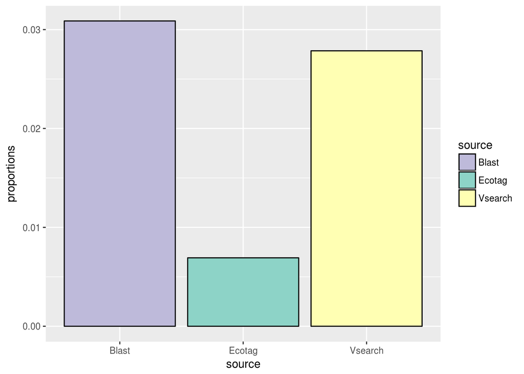

```r
# bar plot of proportion assigned at species level
df <- cbind.data.frame (counts_table$Source, counts_table$species / total_OTUs)
colnames (df) <- c ("source", "proportions")
ggplot (data=df, aes(y=proportions, x=source, fill=source)) + geom_bar(stat="identity", color = "black" ) + scale_fill_manual(values=c("#bebada", "#8dd3c7", "#ffffb3"))
```

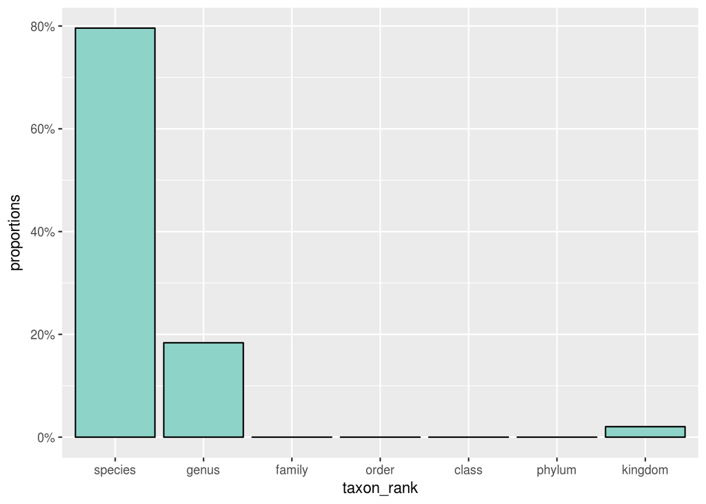

```r
# bar plot rank assignments for Ecotag
proportions <- unlist (counts_table[2,][2:8][1,] / sum (counts_table[2,][2:8][1,] ))
df <- cbind.data.frame (proportions, taxonomicRanksOfInterest)
df <- data.frame(taxon_rank = taxonomicRanksOfInterest, proportions)
ggplot (data=df, aes(y=proportions, x=taxon_rank)) + geom_bar(stat="identity", fill = "#8dd3c7", color = "black") + scale_x_discrete (limits = taxonomicRanksOfInterest) + scale_y_continuous(labels = scales::percent)
```

```r
uniqRanks <- cbind ( c ("Vsearch", "Ecotag", "Blast"), rbind (
apply(vsearch_taxonomy, MARGIN = 2, FUN = function (x) length (unique(x))),
apply(ecotag_taxonomy, MARGIN = 2, FUN = function (x) length (unique(x))),
apply(blast_taxonomy, MARGIN = 2, FUN = function (x) length (unique(x))) ) )
colnames (uniqRanks)[1] <- "Source"
print (uniqRanks)
```

```
##      Source    species genus family order class phylum kingdom
## [1,] "Vsearch" "153"   "135" "93"   "53"  "21"  "13"   "3"
## [2,] "Ecotag"  "38"    "44"  "36"   "27"  "14"  "10"   "3"
## [3,] "Blast"   "157"   "138" "96"   "54"  "22"  "13"   "3"
```

```r
intersect_taxonomy <- function (A, B){
  intersect_lens <- c ()
  for (i in taxonomicRanksOfInterest){
    intersect_lens <- c (intersect_lens, ( length ( intersect ( unlist (unique (A[i])), unlist (unique (B[i])) ) )) )
  }
  intersect_lens
}

intersect_taxonomy_three <- function (A, B, C){
  intersect_lens <- c ()
  for (i in taxonomicRanksOfInterest){
    inter_AB <- intersect (unlist (unique (A[i])), unlist (unique (B[i])) )
    intersect_lens <- c (intersect_lens, ( length ( intersect ( inter_AB, unlist (unique (C[i])) ) )) )
  }
  intersect_lens
}

intersect_counts_EV <- intersect_taxonomy(A = vsearch_taxonomy, B = ecotag_taxonomy)
intersect_counts_EB <- intersect_taxonomy(A = ecotag_taxonomy, B = blast_taxonomy)
intersect_counts_BV <- intersect_taxonomy(A = vsearch_taxonomy, B = blast_taxonomy)
intersect_counts_EBV <- intersect_taxonomy_three(A = vsearch_taxonomy, B = ecotag_taxonomy, C = blast_taxonomy)
intersect_counts_table <- cbind.data.frame (intersect_counts_EV, intersect_counts_EB, intersect_counts_BV, intersect_counts_EBV)
colnames (intersect_counts_table) <- c ("Vsearch, Ecotag", "Ecotag, Blast", "Vsearch, Blast", "Vsearch, Ecotag, Blast")

print (intersect_counts_table)
```

```
##   Vsearch, Ecotag Ecotag, Blast Vsearch, Blast Vsearch, Ecotag, Blast
## 1              30            29            139                     28
## 2              42            41            131                     41
## 3              34            33             91                     33
## 4              26            25             51                     25
## 5              14            14             21                     14
## 6              10            10             13                     10
## 7               3             3              3                      3
```

```r
uniqRanks <- cbind ( c ("Vsearch", "Ecotag", "Blast"), rbind (
apply(vsearch_taxonomy, MARGIN = 2, FUN = function (x) length (unique(x))),
apply(ecotag_taxonomy, MARGIN = 2, FUN = function (x) length (unique(x))),
apply(blast_taxonomy, MARGIN = 2, FUN = function (x) length (unique(x))) ) )
colnames (uniqRanks)[1] <- "Source"

print (uniqRanks)
```

```
##      Source    species genus family order class phylum kingdom
## [1,] "Vsearch" "153"   "135" "93"   "53"  "21"  "13"   "3"
## [2,] "Ecotag"  "38"    "44"  "36"   "27"  "14"  "10"   "3"
## [3,] "Blast"   "157"   "138" "96"   "54"  "22"  "13"   "3"
```

```r
# Get counts of specific unique ranks within a level
vsearch_taxonomy_uniq <- apply(vsearch_taxonomy, MARGIN = 2, FUN = function (x) unique(x))
ecotag_taxonomy_uniq <- apply(ecotag_taxonomy, MARGIN = 2, FUN = function (x) unique(x))
blast_taxonomy_uniq <- apply(blast_taxonomy, MARGIN = 2, FUN = function (x) unique(x))

# Vsearch class counts
vsearch_class_counts <- sapply (vsearch_taxonomy_uniq$class, FUN = function (x) length (which(vsearch_taxonomy$class == x)))
vsearch_phylum_counts <- sapply (vsearch_taxonomy_uniq$phylum, FUN = function (x) length (which(vsearch_taxonomy$phylum == x)))
vsearch_kingdom_counts <- sapply (vsearch_taxonomy_uniq$kingdom, FUN = function (x) length (which(vsearch_taxonomy$kingdom == x)))

# Ecotag class counts
ecotag_class_counts <- sapply (ecotag_taxonomy_uniq$class, FUN = function (x) length (which(ecotag_taxonomy$class == x)))
ecotag_phylum_counts <- sapply (ecotag_taxonomy_uniq$phylum, FUN = function (x) length (which(ecotag_taxonomy$phylum == x)))
ecotag_kingdom_counts <- sapply (ecotag_taxonomy_uniq$kingdom, FUN = function (x) length (which(ecotag_taxonomy$kingdom == x)))

# Blast class counts
blast_class_counts <- sapply (blast_taxonomy_uniq$class, FUN = function (x) length (which(blast_taxonomy$class == x)))
blast_phylum_counts <- sapply (blast_taxonomy_uniq$phylum, FUN = function (x) length (which(blast_taxonomy$phylum == x)))
blast_kingdom_counts <- sapply (blast_taxonomy_uniq$kingdom, FUN = function (x) length (which(blast_taxonomy$kingdom == x)))

print (vsearch_class_counts)
```

```
##        Malacostraca         Maxillopoda         Actinopteri
##                  23                  10                  88
##         Cephalopoda         Sagittoidea            Mammalia
##                   5                   1                   6
##          Gastropoda           Oomycetes           Ostracoda
##                   4                   1                   1
##             Insecta      Eurotiomycetes
##                   3                   1                   4
##         Dinophyceae    Prymnesiophyceae                Aves
##                   1                   1                   1
##      Chondrichthyes         Ophiuroidea            Hydrozoa
##                   2                   1                   2
## Coscinodiscophyceae     Sordariomycetes  Microbotryomycetes
##                   1                   2                   1
```

```r
print (ecotag_class_counts)
```

```
##        Maxillopoda        Actinopteri       Malacostraca
##                  7                 24                  2
##           Mammalia         Gastropoda        Dinophyceae
##                  5                  2                  1
##        Cephalopoda   Prymnesiophyceae               Aves
##                  1                  1                  1
##        Ophiuroidea           Hydrozoa Microbotryomycetes
##                  1                  1                  1
##                       Sordariomycetes
##                  1                  1
```

```r
print (blast_class_counts)
```

```
##        Malacostraca         Maxillopoda         Actinopteri
##                  24                  10                  98
##         Cephalopoda         Sagittoidea            Mammalia
##                   5                   1                   7
##          Gastropoda      Eurotiomycetes           Oomycetes
##                   4                   2                   1
##           Ostracoda     Sordariomycetes             Insecta
##                   1                   3                   4
##                             Dinophyceae    Prymnesiophyceae
##                   2                   1                   1
##                Aves      Chondrichthyes         Ophiuroidea
##                   1                   3                   1
##            Hydrozoa Coscinodiscophyceae     Dothideomycetes
##                   2                   1                   1
##  Microbotryomycetes
##                   1
```

```r
print (vsearch_phylum_counts)
```

```
##       Arthropoda         Chordata         Mollusca     Chaetognatha
##               37               98                9                1
## Heterokontophyta       Ascomycota  Pyrrophycophyta
##                1                3                1                3
##       Haptophyta    Echinodermata         Cnidaria  Bacillariophyta
##                1                1                2                1
##    Basidiomycota
##                1
```

```r
print (ecotag_phylum_counts)
```

```
##      Arthropoda        Chordata        Mollusca Pyrrophycophyta
##               9              30               3               1
##      Haptophyta   Echinodermata        Cnidaria   Basidiomycota
##               1               1               1               1
##                      Ascomycota
##               1               1
```

```r
print (blast_phylum_counts)
```

```
##       Arthropoda         Chordata         Mollusca     Chaetognatha
##               39              110                9                1
##       Ascomycota Heterokontophyta  Pyrrophycophyta       Haptophyta
##                6                1                1                1
##                     Echinodermata         Cnidaria  Bacillariophyta
##                1                1                2                1
##    Basidiomycota
##                1
```

```r
print (vsearch_kingdom_counts)
```

```
## Metazoa           Fungi
##     148       7       4
```

```r
print (ecotag_kingdom_counts)
```

```
## Metazoa           Fungi
##      45       2       2
```

```r
print (blast_kingdom_counts)
```

```
## Metazoa   Fungi
##     162       7       5
```

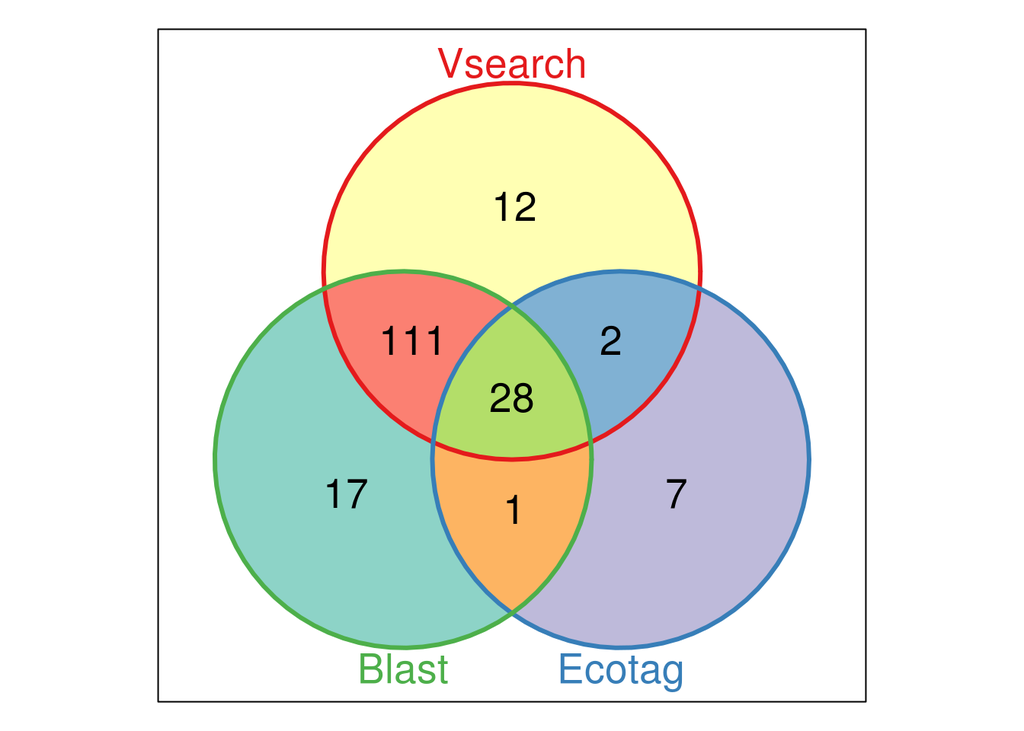

```r
par(mfrow=c(1,3))
vn_species <- list (0)
vn_species[[1]] <- vsearch_taxonomy_uniq$species
vn_species[[2]] <- ecotag_taxonomy_uniq$species
vn_species[[3]] <- blast_taxonomy_uniq$species
names (vn_species) <- c ("Vsearch", "Ecotag", "Blast")
plot (Venn (vn_species), doWeights = FALSE)
```

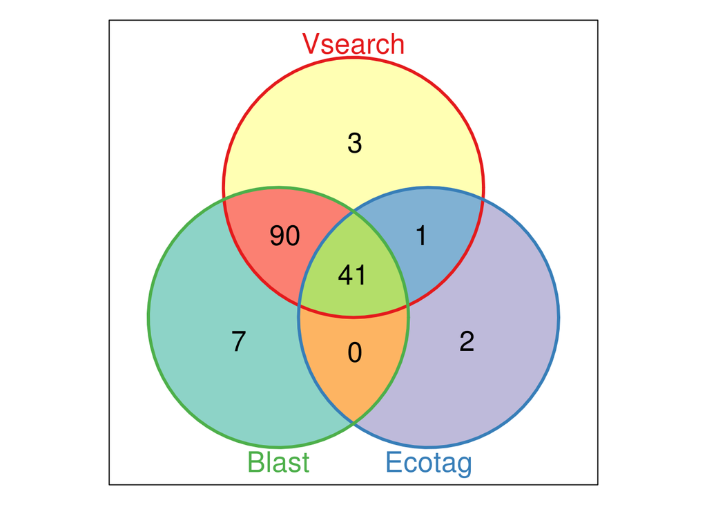

```r
vn_genus <- list (0)
vn_genus[[1]] <- vsearch_taxonomy_uniq$genus
vn_genus[[2]] <- ecotag_taxonomy_uniq$genus
vn_genus[[3]] <- blast_taxonomy_uniq$genus
names (vn_genus) <- c ("Vsearch", "Ecotag", "Blast")
plot (Venn (vn_genus), doWeights = FALSE)
```

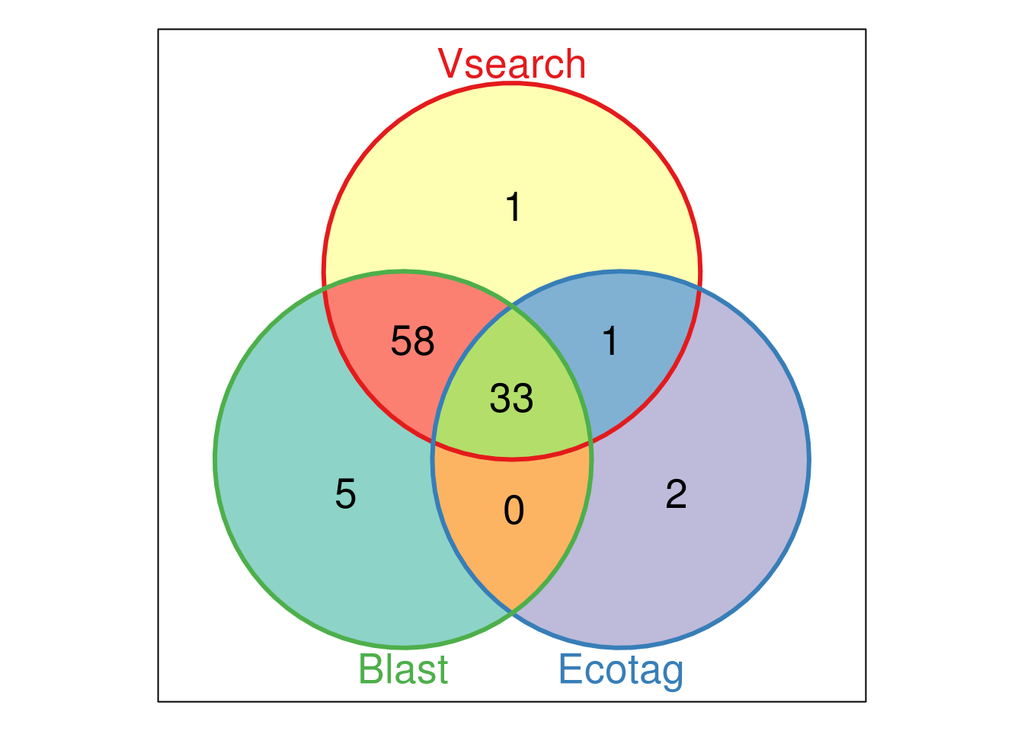

```r
vn_family <- list (0)
vn_family[[1]] <- vsearch_taxonomy_uniq$family
vn_family[[2]] <- ecotag_taxonomy_uniq$family
vn_family[[3]] <- blast_taxonomy_uniq$family
names (vn_family) <- c ("Vsearch", "Ecotag", "Blast")
plot (Venn (vn_family), doWeights = FALSE)
```

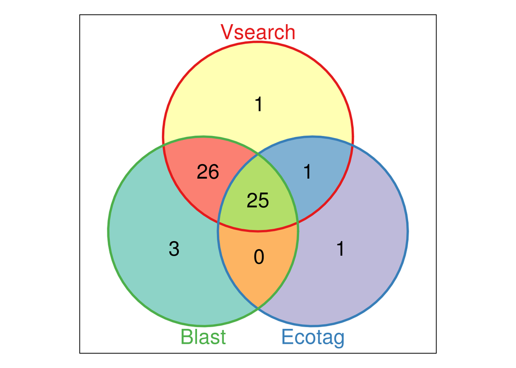

```r
vn_order <- list (0)
vn_order[[1]] <- vsearch_taxonomy_uniq$order
vn_order[[2]] <- ecotag_taxonomy_uniq$order
vn_order[[3]] <- blast_taxonomy_uniq$order
names (vn_order) <- c ("Vsearch", "Ecotag", "Blast")
plot (Venn (vn_order), doWeights = FALSE)
```

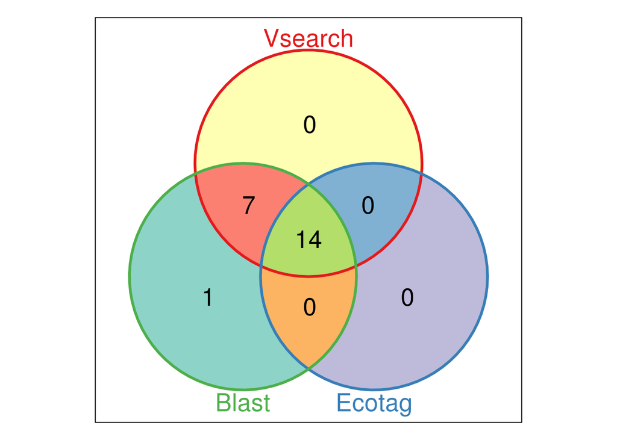

```r
vn_class <- list (0)
vn_class[[1]] <- vsearch_taxonomy_uniq$class
vn_class[[2]] <- ecotag_taxonomy_uniq$class
vn_class[[3]] <- blast_taxonomy_uniq$class
names (vn_class) <- c ("Vsearch", "Ecotag", "Blast")
plot (Venn (vn_class), doWeights = FALSE)
```

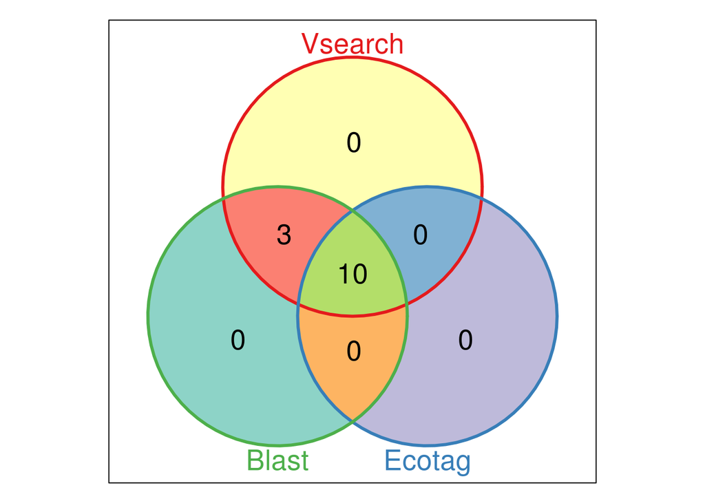

```r
vn_phylum <- list (0)
vn_phylum[[1]] <- vsearch_taxonomy_uniq$phylum
vn_phylum[[2]] <- ecotag_taxonomy_uniq$phylum
vn_phylum[[3]] <- blast_taxonomy_uniq$phylum
names (vn_phylum) <- c ("Vsearch", "Ecotag", "Blast")
plot (Venn (vn_phylum), doWeights = FALSE)
```

## Investigate preditors

```r
Predators_Samples$SAMPLE_ID <- make.names (Predators_Samples$SAMPLE_ID)

# Build critters vs tubes

##ovt_vsearch[ovt_vsearch$species == "Pseudorhombila quadridentata", "X558.A"]

# Fix a sample ID error
colnames (ovt_vsearch) <- gsub (x = colnames (ovt_vsearch), pattern = "B0", replacement = "B")
colnames (ovt_ecotag) <- gsub (x = colnames (ovt_ecotag), pattern = "B0", replacement = "B")
colnames (ovt_blast) <- gsub (x = colnames (ovt_blast), pattern = "B0", replacement = "B")

predator_match_vsearch <- apply (X = Predators_Samples, MARGIN = 1, FUN = function (x) { sum(ovt_vsearch[ovt_vsearch$species == x[2], x[1]])  })
predator_match_len_vsearch <- length (which (sapply (X = predator_match_vsearch, FUN = function (x) {x > 0})))
predator_match_proportion_vsearch <- predator_match_len_vsearch / length (samples)

predator_match_ecotag <- apply (X = Predators_Samples, MARGIN = 1, FUN = function (x) { sum (ovt_ecotag[ovt_ecotag$species == x[[2]], x[[1]]])  })
predator_match_len_ecotag <- length (which (sapply (X = predator_match_ecotag, FUN = function (x) {x > 0})))
predator_match_proportion_ecotag <- predator_match_len_ecotag / length (samples)

predator_match_blast <- apply (X = Predators_Samples, MARGIN = 1, FUN = function (x) { sum (ovt_blast[ovt_blast$species == x[[2]], x[[1]]])  })
predator_match_len_blast <- length (which (sapply (X = predator_match_blast, FUN = function (x) {x > 0})))
predator_match_proportion_blast <- predator_match_len_blast / length (samples)

predator_match_proportions <- cbind.data.frame ( c ("Vsearch", "Ecotag", "Blast"),
                                                c (predator_match_proportion_vsearch, predator_match_proportion_ecotag, predator_match_proportion_blast))
colnames(predator_match_proportions) <- c ("source", "proportions")


p1 <- ggplot (data=predator_match_proportions, aes(y=proportions, x=source, fill=source)) + geom_bar(stat="identity", color = "black" ) + scale_fill_manual(values=c("#bebada", "#8dd3c7", "#ffffb3")) + ylim(0,1)
```

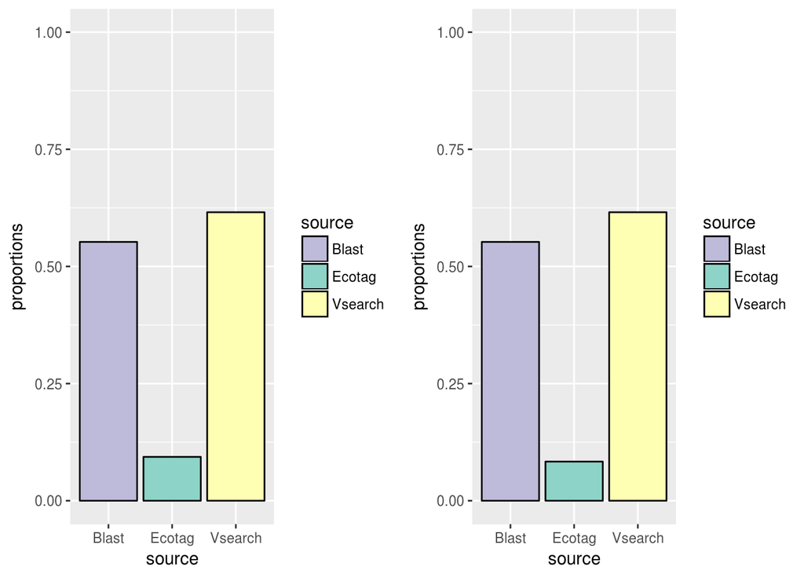

```r
##ovt_vsearch[ovt_vsearch$species == "Sardinella aurita", "X1049.G"]

# Fix a sample ID error
colnames (ovt_vsearch_97) <- gsub (x = colnames (ovt_vsearch), pattern = "B0", replacement = "B")
colnames (ovt_ecotag_97) <- gsub (x = colnames (ovt_ecotag), pattern = "B0", replacement = "B")
colnames (ovt_blast_97) <- gsub (x = colnames (ovt_blast), pattern = "B0", replacement = "B")

predator_match_vsearch <- apply (X = Predators_Samples, MARGIN = 1, FUN = function (x) { sum (ovt_vsearch_97[ovt_vsearch_97$species == x[[2]], x[[1]]])  })
predator_match_len_vsearch <- length (which (sapply (X = predator_match_vsearch, FUN = function (x) {x > 0 })))
predator_match_proportion_vsearch <- predator_match_len_vsearch / length (samples)

predator_match_ecotag <- apply (X = Predators_Samples, MARGIN = 1, FUN = function (x) { sum (ovt_ecotag_97[ovt_ecotag_97$species == x[[2]], x[[1]]])  })
predator_match_len_ecotag <- length (which (sapply (X = predator_match_ecotag, FUN = function (x) {x > 0 })))
predator_match_proportion_ecotag <- predator_match_len_ecotag / length (samples)

predator_match_blast <- apply (X = Predators_Samples, MARGIN = 1, FUN = function (x) { sum (ovt_blast_97[ovt_blast_97$species == x[[2]], x[[1]]])  })
predator_match_len_blast <- length (which (sapply (X = predator_match_blast, FUN = function (x) {x > 0})))
predator_match_proportion_blast <- predator_match_len_blast / length (samples)

predator_match_proportions_97 <- cbind.data.frame ( c ("Vsearch", "Ecotag", "Blast"),
                                                c (predator_match_proportion_vsearch, predator_match_proportion_ecotag, predator_match_proportion_blast))
colnames(predator_match_proportions_97) <- c ("source", "proportions")

p2 <- ggplot (data=predator_match_proportions_97, aes(y=proportions, x=source, fill=source)) + geom_bar(stat="identity", color = "black" ) + scale_fill_manual(values=c("#bebada", "#8dd3c7", "#ffffb3")) + ylim(0,1)

grid.arrange(p1, p2, ncol=2)
```